# 汽车行业 117 年：从福特到中国 EV 北美攻防战

更新日期：2026年5月21日

写给从科技与广告行业转型加拿大 EV BD 的求职者与从业者。

如果你下周要和一家中国电池厂的北美业务负责人开会，对方第一句话说：“我们在评估墨西哥和加拿大两条路线，你怎么看 USMCA 的 75% 本地化要求和安大略的产业政策？”——你能在三十秒内接上吗？

不需要把过去 117 年汽车业的每个细节背下来。但你需要在这五个维度上立刻能反应：

- **OEM**（整车厂）格局怎么走到今天，Big 3、丰田、本田、现代起亚、Tesla、比亚迪现在分别站在哪里
- **Dealer**（经销商）法律壁垒——为什么 Tesla 在美国 50 个州各打一场仗，加拿大为什么不一样
- **Charging**（充电）网络从 CCS 到 NACS 的洗牌——这对一家中国 EV 想进北美意味着什么
- **Battery**（电池）供应链——锂矿在哪、谁加工、谁做电芯、为什么”中国控制电池”不是夸张
- **政策**——IRA、Section 301、UFLPA、加拿大 100% 关税与 2026 年的配额松动

这本手册不假装能让你一周变成 30 年老炮。它要做的事更窄：让你在 BD 对话里，每个关键词都能接上——不是背名词，而是知道这个名词背后是哪个 1908 年的决定、哪一份 2024 年 9 月的 USTR 公告、哪家公司的哪一笔 2025 年财报损失。

读完 14 章，你具备的是 BD 对话的**底盘**——看到一条新闻，能识别”这是哪个力量在动”；听到对方提”NUMMI”或”Sloan”或”NACS”，能立刻把它放回这 117 年的叙事里；遇到中国客户讨论”出海加拿大”，能跟他在数据层面而不是口号层面对话。

下面是路线。

第 1-4 章是历史压舱：福特、Sloan、丰田、Big 3 崩盘。这部分压缩会让后面的”现在”失去深度。第 5-6 章是电动车的起点和反转：Tesla 怎么把笑话变成主流，中国 EV 怎么在 2024 年完成超车。第 7-10 章是 BD 对话的硬通货：电池、充电、经销商法、美国政策三道墙。第 11-13 章把镜头拉回加拿大：加拿大跟美国的差别、北美 OEM 的当下战略、中国车企的真实出海路径。第 14 章是 BD 实战工具箱：人物地图、媒体地图、对话钩子。

> **数据截止日：2026 年 5 月。** 关税、市场份额、政策细节每季度都在变。如果你是几个月之后才读到这份手册，请把里面所有数字当成”那一时刻的快照”，不要直接拿去面试或对客户报价——文末”参考资料”列出了每条数字的原始链接，回去重新核对一次。

数据问题先说三条规矩：

第一，任何 2024-2025 的销量 / 份额 / 关税数字，本手册都标了来源，并在文末”参考资料”列出原始链接。建议你在面试前 48 小时重新点开这些链接核对最新版本——这个行业每个季度都会刷新。

第二，本手册不点名当下还在职的具体高管。所有”决策人物地图”按角色和公司动作描述。原因是这个层级的人三个月就可能换岗，把名字背进面试反而成为短板。

第三，凡是只有一家分析师或一篇博客说过的销售预测、生存概率、市场份额排名，本手册标为”分析师观点”，不当事实引用。

我们开始。

## 第1章 福特：把汽车从富人玩具变成大众商品

### 1.1 1908 年之前，汽车不是工业，是手工艺

想象 1900 年的底特律。当时全美生产汽车的工厂有几百家，每家年产量几十到几百台。一辆车的售价相当于今天的好几年家庭收入——它是富人的玩具，跟今天的私人飞机差不多定位。

那时候没有”汽车行业”。有的是分散的手工作坊：每台车几乎都是定制的，工人在车架旁边走来走去，一个人负责装一台车的多个零件，工具堆在一边，零件堆在另一边。一台车从开工到下线，要几百个工时。

亨利·福特 1903 年成立福特汽车公司时，他的对手不是别的车厂——他的对手是”汽车是奢侈品”这个事实本身。他要解决的问题是：怎么让一个工厂工人，能买得起自己工厂造的车？

这件事的答案，决定了后来 117 年汽车工业的所有底层逻辑。

### 1.2 1908 年的 Model T：先有产品，再有工业

1908 年 10 月，Model T 上市，初代售价约 850 美元——已经比当时同级车便宜，但还不够便宜。

Model T 的设计选择极端到今天还在工业设计教科书里：只生产一种车型、一种颜色（“任何颜色，只要它是黑的”——这句名言出现得稍晚，是车型简化策略的产物）、零件标准化到任何人在任何地方都能换。

这看起来是”产品决策”，本质上是”为流水线做准备”。一台车只有一种规格，意味着工厂里所有工序可以固定下来，每个工位只做一件事，工人不需要在不同的车型之间切换工具和动作。

### 1.3 1913 年 12 月：流水线点燃

1908 年福特公司在底特律 Highland Park 建了一座新工厂。1910 年生产正式搬入。1913 年 12 月 1 日，Highland Park 的磁电机装配线启动——这是工业史上第一条真正意义上的连续移动流水线（assembly line）。

变化是立竿见影的。在流水线之前，装配一台 Model T 底盘需要 12 小时 30 分钟；流水线投产后，时间压缩到 1 小时 33 分钟。同样的工厂、同样的工人数量，产量提升了 8 倍以上。

Model T 的售价从 1908 年的约 850 美元，一路降到 1925 年的 260 美元附近。这不是”工业逐渐进步”——这是结构性产能爆炸。

### 1.4 1914 年的”五美元日”：另一半才是工业革命

但流水线本身不够。流水线工作枯燥、重复、节奏快——工人流失率极高。1913 年福特工厂的年度工人流失率超过 370%。

1914 年 1 月，福特宣布把工人最低日薪提到 5 美元，约为当时市价的两倍，工时从 9 小时减到 8 小时。这一步通常被叙述成”福特对工人慷慨”，但放回工业逻辑看，它解决的是流水线无法解决的另一半问题：稳定的劳动力。

工资翻倍 + 工时缩短 + 标准化生产，让一件原本不可能的事变得可能：**福特工厂的工人，自己买得起自己造的车**。

这个闭环——大规模生产降低成本，规模化消费养活规模化生产——成了 20 世纪美国制造业的核心模板，从汽车扩散到家电、消费电子、快餐、零售。

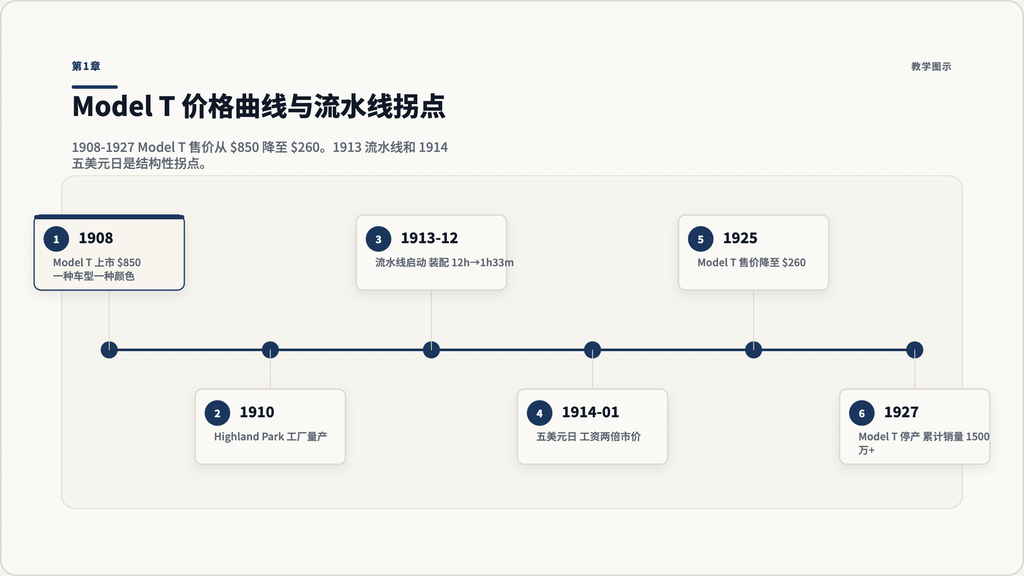

第1章：从手工作坊到大规模生产

**图 1.1：Model T 价格曲线 1908-1927，从 $850 降至 $260。流水线（1913）和五美元日（1914）是结构性拐点，不是渐进改良。**

### 1.5 福特的盲区：单品类、单颜色、单代

Model T 从 1908 卖到 1927，全球累计销量超过 1500 万台。这是 20 世纪上半叶最大的单一车型销售纪录。

但福特把”标准化”推到极致的同时，也把自己锁进了一个产品决策——所有 Model T 几乎一模一样，连续 19 年。

1920 年代中期，美国消费者开始要求选择：不同颜色、不同款式、不同档次。福特反应迟缓。当福特终于在 1927 年停产 Model T、推出 Model A 接班时，已经把市场领先位置交给了通用汽车（GM）——这是第 2 章的故事。

### 1.6 BD 对话的回收点

这一章对 BD 工作有两个直接用处：

第一，当你听到中国电动车厂说”我们要做大规模、低成本、标准化的国民车”，这是 1908 年福特剧本的当代复刻。你应该立刻问：那你怎么处理”消费者要求差异化”这个跟随而来的问题？

第二，当你跟 OEM 高管或电池厂谈”中国速度”时，对方往往把”中国速度”想象成福特剧本——大规模、低成本、单一品类压制对手。但事实上中国 EV 在 2020-2024 年完成的是”多品类、快迭代、用户共创”——这是 GM 在 1930 年代用过的剧本，不是福特剧本。第 2 章会讲为什么这两个剧本根本不同。

### 1.7 章末检查点

读完本章，你应该能用一句话回答：

> “为什么 1913 年的流水线和 1914 年的五美元日，必须配套出现，缺一个都不成立？”

如果答案只有”流水线提高效率”，回到 1.4 再读一次。这里是理解福特模式的关键。

## 第2章 通用：Sloan 用”品牌阶梯”打败 Ford 的逻辑

### 2.1 1920 年代美国市场的换代信号

1920 年代美国汽车市场已经接近饱和：第一波”家里第一辆车”的浪潮过去了。下一波购买者大多是在换车，而不是头一次买车。

换车的人在意什么？颜色、款式、马力、地位象征——而不是”再便宜一点”。福特对此反应迟缓。他相信”一种车造到最便宜”这个公式可以永远跑下去。

通用汽车（GM）在 1923 年迎来了一位关键人物：Alfred P. Sloan 出任总裁。Sloan 不是工程师，他是组织设计师。他的判断是：要打败福特，不是再造一辆更便宜的车，而是**重新设计市场结构本身**。

### 2.2 Sloan 的”品牌阶梯”

Sloan 把 GM 当时旗下的几个互不协调的品牌——Chevrolet、Pontiac（Oakland）、Oldsmobile、Buick、Cadillac——重新整理成一条从低到高的价格阶梯：

- **Chevrolet**：入门，对标 Model T
- **Pontiac**：年轻、运动
- **Oldsmobile**：中产
- **Buick**：中产高端，“医生开的车”
- **Cadillac**：奢华，“成功者的车”

每个品牌覆盖一个价格区间，区间之间几乎没有重叠。一个家庭一生中可以”沿着阶梯往上爬”——年轻时买 Chevrolet，事业有成换 Pontiac，中年坐进 Buick，退休前奖励自己一台 Cadillac。

这个设计今天看起来理所当然，但在 1920 年代是革命性的。它不再问”汽车应该多便宜”，而问”汽车在你的人生里扮演什么角色”。

### 2.3 年度换代：制造时间型需求

Sloan 推动的第二个工具是”年度款型变更”（annual model change）。每年同一款车都会有外观、内饰、马力的微调，让去年的车显得”过时”。

这件事今天我们叫它”计划性淘汰”或”时尚周期”。它把消费者拉进一个心理循环：你的车没坏，但它”老了”，你想换。

合起来看：**品牌阶梯**让消费者横向选择，**年度换代**让消费者纵向更新。两个机制叠加，制造了一个 Model T 那种”造一台开 20 年”模式无法应付的购买频率。

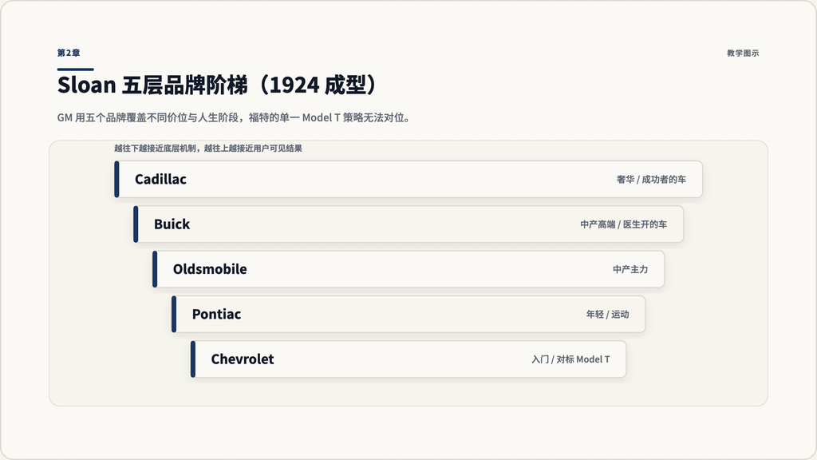

第2章：从单一价格到品牌阶梯

**图 2.1：Sloan 的五层品牌阶梯（1924 年成型）。同一家公司用不同品牌覆盖不同收入和身份段位，福特的单一 Model T 策略无法对位。**

### 2.4 1931 年的市场翻盘

1931 年，通用汽车在美国市场份额第一次超过福特。从那年开始，通用汽车保持全球或美国销量第一长达数十年——直到 2008 年被丰田超过。这是企业史上一次教科书级的”产品逻辑被组织逻辑打败”的案例。

需要说明：Sloan 的”品牌阶梯”并不是凭空发明的。1908 年 GM 收购了多个独立品牌时，这条阶梯雏形已经存在，但混乱无章。Sloan 做的是**清理、定位、分价、不交叉**——这是组织和市场战略层面的功夫，不是工程功夫。

### 2.5 Sloan 留下的两份遗产

Sloan 在 1937 年把总裁位置交出，1956 年退休，留下的不只是一个组织结构，更是两份长期影响：

**第一份遗产：M-Form（多事业部制）。** 总部管财务、研发战略、资源分配；事业部（Chevrolet、Buick、Cadillac 等）管自己品牌的产品、营销、销售。这套结构后来被几乎所有跨国大企业沿用——从杜邦到 GE 到苹果都有它的影子。

**第二份遗产：消费金融。** 1919 年 GM 成立 GMAC（通用汽车承兑公司），让消费者可以分期付款买车。福特长期反对消费贷，认为”借钱买东西是坏习惯”。结果是：GMAC 用金融工具进一步降低了 GM 旗下车的购买门槛——你不需要凑齐 800 美元才能开走 Buick，你每月还几十美元就行。

这两份遗产对后世的意义远超汽车业。今天 Tesla 销售时给你即时按揭报价、Apple 用 Card 提供分期、BMW 用品牌矩阵分覆盖不同段位——背后都是 Sloan 模板。

### 2.6 福特之子的反击：迟到 25 年

亨利·福特本人到死都拒绝接受”市场需要多样化”。Model T 停产、Model A 上市后，福特公司在 1930-1950 年代一直追着 GM 跑。直到亨利·福特的孙子（Henry Ford II）在 1945 年接手公司、引入麦克纳马拉为首的”神童团队”——一群刚从二战军方分析部门退役的年轻管理者——福特才重新构建了类似 Sloan 的现代管理结构。

但市场份额已经永久性地让出去了。福特直到今天都是美国汽车业的”第二名”，从未真正夺回 GM 在 1931 年抢走的位置。

### 2.7 BD 对话的回收点

第一，今天看中国 EV 玩家——比亚迪用”王朝系列 / 海洋系列 / 腾势 / 仰望” 覆盖从 8 万到 100 万人民币——这是教科书级的 Sloan 阶梯。当你跟比亚迪海外团队对话，理解他们已经用过 Sloan 剧本，不要把他们和早期 Tesla（单一品类策略）混为一谈。

第二，“品牌阶梯”对加拿大 EV 市场的意味是：如果你是一家中国 EV 厂家进加拿大，你的产品组合不能只投一台车型。加拿大市场分层很碎——魁北克、安大略、卑诗省的消费者画像差异巨大。如果只投一个 SKU，必然丢掉至少 60% 的可触达市场。

第三，Sloan 的另一条遗产——消费金融——今天是 EV 销售的关键工具。一台 5 万加元的电动 SUV 不靠按揭、不靠租赁残值担保（lease residual），是卖不掉的。这是你跟加拿大 dealer 或 OEM 谈合作时必须立刻能聊的话题。

### 2.8 章末检查点

> “为什么 GM 在 1931 年超过福特之后，福特用了大半个世纪都没有真正夺回第一？”

如果你的答案是”GM 车更好”，再读一遍 2.2 和 2.5。这场胜利的核心不是产品，是产品组织方式和金融工具。

## 第3章 日系反攻：1973 年的石油弹和丰田生产方式

### 3.1 1973 年 10 月之前，美国车主没考虑过油耗

1972 年的底特律 Big 3（GM、Ford、Chrysler）站在巅峰：联合占据美国市场约 85%。轿车越来越大、越来越重、越来越耗油——但没人在意，因为汽油几乎不要钱。1972 年美国零售油价大约每加仑 0.36 美元。

然后 1973 年 10 月，OAPEC（阿拉伯石油输出国组织）对支持以色列的国家实施石油禁运。

到 1974 年 1 月，美国油价飙到每加仑 0.84 美元——半年内翻倍以上，加油站排长队成为常态，一些州实行车牌单双号限购。

第二次冲击来得更快：1979 年伊朗革命又一次切断石油供应，油价再次翻倍。

美国消费者第一次真正在意一件事：这台车每加仑能跑多远。

### 3.2 Big 3 的产品组合：完全没准备

1973 年时，美国本土生产的轿车平均油耗大约 14 英里每加仑。日本生产的本田 Civic、丰田 Corolla 平均油耗 30 英里每加仑以上——而且价格更便宜。

突然之间，进 dealer 看车的美国消费者不再问”你这台有多大马力？“，他们问”省不省油？”

Big 3 的车型库里几乎没有省油车型。Chrysler 一度尝试卖法国和欧洲产的小车救场，未能止住失血。1976-1980 短短四年间，日系车在美国市场份额从约 9% 跃升到约 21%。

但这不只是石油危机的功劳。

### 3.3 丰田生产方式（TPS）：精益的根

1973 年时丰田已经有一套独特的生产体系——TPS（Toyota Production System），后来在西方世界以”精益生产”（Lean Manufacturing）的名字传开。

TPS 由丰田佐吉、丰田喜一郎、大野耐一三代人在 1930-1970 年代逐步打磨成形。两个核心机制：

**Just-in-Time（准时制）：** 零件不堆在仓库里。需要时才从上一道工序流过来。这看起来是”省仓库费用”——本质上是**强制暴露所有问题**：任何工序出错，整条生产线立刻停，所有人立刻知道。

**Jidoka（自働化，“带智慧的自动化”）：** 任何工人发现质量问题，可以拉绳停线——andon 系统。在福特/GM 的工厂里，工人不敢停线（管理层会惩罚停线工）；在丰田，停线是被鼓励的，因为不停线只会让坏品流到下一道工序。

TPS 还有第三个隐形机制：**Kaizen（改善）**——所有改进意见从一线工人发起，自下而上的微小优化每天积累。

### 3.4 美国汽车业 30 年没看懂

1980 年代美国制造业派了一波又一波”考察团”去丰田工厂学习。回来后许多公司学到的只是”看板”（kanban）卡片和”5S”（整理、整顿、清扫、清洁、素养）——这是 TPS 的表面工具，不是它的逻辑内核。

逻辑内核是：**让问题立刻暴露 + 让一线工人有权改进**。这两条触及美国制造业的组织假设——“工人执行命令”——所以学不动。

直到 1984 年，GM 和丰田合资在加州 Fremont 开了 NUMMI 工厂（New United Motor Manufacturing Inc.），把同一群曾经被 GM 评为”全国最难管”的美国工人，用 TPS 训练。两年后这家工厂的生产质量从 GM 系统垫底变成最高。

NUMMI 证明了一件事：**问题不在工人，问题在系统**。这件事极其重要，但 GM 没能把 NUMMI 的方法横移到自己其他工厂——因为那需要重新设计整个公司的权力结构。

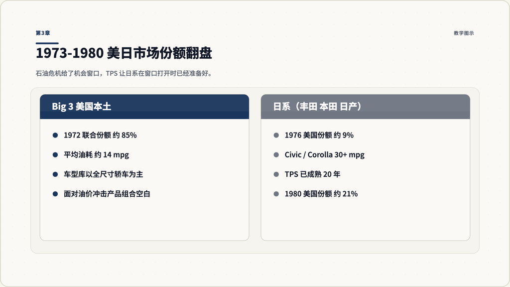

第3章：1973-1980 美日市场份额翻盘

### 3.5 CAFE：政策跟在市场后面

1975 年美国国会通过 CAFE 标准（Corporate Average Fuel Economy），要求汽车厂全队平均油耗每年提升。这是政策第一次试图用强制手段拉近 Big 3 和日系的差距——结果是又一波”小车研发”压力。

CAFE 后来成了美国 EV 政策的远祖。今天你在 BD 对话里听到”CARB”（加州空气资源局）或”ZEV mandate”（零排放车辆要求），都是 CAFE 的延伸版本。

### 3.6 日系崛起的第三波：本田 + 日产

1980 年代日本车厂在美国遇到本土反弹（“日本车抢走美国人工作”），于是日系厂家选择直接到美国建厂：

- **本田**1982 年俄亥俄 Marysville 工厂——是日本厂家第一座美国整车厂
- **日产**1983 年田纳西 Smyrna 工厂
- **丰田**先通过 NUMMI 学习美国本土生产，1988 年单独在肯塔基 Georgetown 建厂

这一波”现地生产”策略——后来叫”trans-plant”——让日系一边躲过贸易壁垒，一边在美国本土雇美国工人，一定程度上消解了反日情绪。这套剧本今天比亚迪、奇瑞试图在墨西哥重演（第 13 章会讲）。

### 3.7 BD 对话的回收点

第一，当你今天听到”美国制造业空心化”，回到 1973-1980 这八年。Big 3 没在”省油车”这件事上准备好的代价，是丢了 12 个市场份额点，再也没回来。

第二，TPS 的逻辑内核是”暴露问题 + 一线赋权”。这个内核在今天的电池工厂、Tesla 工厂、比亚迪深圳工厂仍然是底层逻辑。如果一家 OEM 跟你说”我们也用精益”，下一句你要问”你的工人有权停线吗？管理层惩罚停线吗？“——这两个问题立刻能分辨真假精益。

第三，1980 年代日系”trans-plant”策略——直接在销售国建厂——是今天中国 EV 必须复刻的剧本。如果只靠出口，关税壁垒永远卡死你。

### 3.8 章末检查点

> “1976-1980 年日系车美国市场份额涨了大约 12 个百分点。其中多少是石油危机给的，多少是 TPS 给的？”

如果你的答案是”100% 石油危机”或”100% TPS”，都不对。两个力量必须同时存在——油价冲击给了机会窗口，TPS 让日系车在窗口打开时已经准备好了产品和产能。Big 3 既没有产品也没有产能，所以只能眼看着市场份额流走。

## 第4章 Big 3 的崩塌：从 NUMMI 到 2008 救助

### 4.1 1980-2000：被慢慢吃掉的二十年

1980 年代之后 Big 3 没有再失去市场份额？是失去了。但失去的速度慢——每年 0.5 到 1 个百分点。慢到管理层每年都觉得”明年会反弹”，每年都没有反弹。

到 2007 年，Big 3 在美国合计市场份额跌破 50%。同一时期他们累积了一些结构性负担：

**第一负担：高额养老金和医疗承诺。** 1950-1970 年代 Big 3 跟 UAW（汽车工人工会）签的合约里，承诺退休员工终身医疗。到 2007 年，仅 GM 一家就有约 50 万退休员工和家属——他们的医保账单每年达到几十亿美元。GM 高管曾经说过一句出名的话：“我们是一家提供医疗保险的公司，顺便造车。”

**第二负担：品牌过剩。** 通用汽车 2007 年仍维持 8 个品牌——Chevrolet、Pontiac、Oldsmobile（2004 才停产）、Buick、Cadillac、GMC、Saturn、Hummer、Saab。每个品牌都需要独立的设计、营销、经销商网络。Sloan 1924 年的五层阶梯已经膨胀成八九个互相打架的子部门。

**第三负担：SUV / 卡车依赖。** 2000-2007 年 Big 3 的利润几乎全部来自高利润的全尺寸 SUV 和皮卡——Ford F-150、GM Suburban、Dodge Ram 等。这套利润结构在油价低时挣大钱，在油价上涨时立刻塌方。

### 4.2 2008 年 9 月：信用市场冻结

2008 年 9 月雷曼兄弟倒闭，全球信用市场冻结。汽车厂的两条生命线同时断：

**消费端：** 消费者买车 80-90% 靠贷款，信用冻结意味着 dealer 卖不出车。 **生产端：** OEM 自己的循环贷被砍，付不出供应商货款。

加上 2008 年油价飙到 4 美元 / 加仑——SUV 销售崩盘，Big 3 的利润奶牛同时被牵走。

到 2008 年 11 月，GM 和 Chrysler 公开告知国会，如果没有政府救助，他们将在几周内现金流枯竭。

### 4.3 TARP 与”汽车救助”：$85B 的剧本

加上加拿大政府对 GM Canada 和 Chrysler Canada 的救助，**美加两国合计投入约 850 亿美元**救助北美汽车业。这是工业史上单次最大规模的产业救助。

需要说明：850 亿这个数字包含加拿大投入的部分（约 100 亿加元）。如果只算美国财政部直接投入，约 800 亿美元。两个数字都常见，看上下文。

### 4.4 救助的结果：清算 + 重启

GM 在破产保护期间做了一件几十年没敢做的事——砍品牌。Pontiac、Saturn、Hummer 全部砍掉，Saab 卖给中国吉利系（后来又破产）。GM 出来时只剩 4 个品牌：Chevrolet、Buick、Cadillac、GMC。

Chrysler 被 Fiat 收购，2014 年合并为 Fiat Chrysler Automobiles（FCA）。2021 年 FCA 又跟法国 PSA（Peugeot-Citroën）合并，组成今天的 Stellantis 集团——14 个品牌的跨大西洋集团，其中北美主力是 Chrysler / Dodge / Jeep / Ram。

UAW 也被迫接受新员工”两级工资制”（two-tier wages）——新员工的起薪和福利比老员工低得多。这个调整长期降低了 Big 3 的劳动力成本，但也埋下了 2023 年 UAW 大罢工的种子。

### 4.5 丰田 2008 年成为全球销量第一

同样是 2008 年，丰田超过 GM 成为全球销量第一。这是 1931 年 GM 取代福特以来，全球汽车销量榜首第一次易主。

丰田没有依赖救助，因为它没有 Big 3 那种养老金和医保的结构负担——日本企业养老金体系由国家+企业混合承担，不是 Big 3 那种”企业终身负担”模式。

GM 后来在 2010-2012 间短暂夺回全球第一，但从 2014 起，丰田和大众长期轮流坐第一第二，GM 在第三或更后。

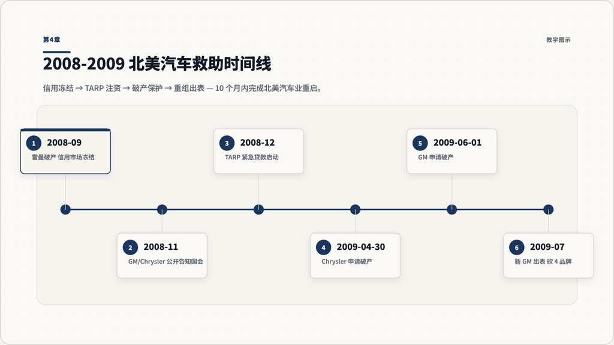

第4章：2008-2009 年北美汽车救助时间线

**图 4.1：2008 年 9 月信用冻结到 2009 年 7 月 GM 走出破产保护，10 个月的政府介入、品牌清算、工会让步。Ford 是唯一拒绝 TARP 的 Big 3。**

### 4.6 NUMMI 的尾声：象征性的关闭

2010 年 GM 退出 NUMMI（破产重组中切割掉的产能之一）。同年丰田也宣布退出。这家曾经证明”美国工人能学会 TPS”的工厂关闭——然后被一家小公司接手。

这家小公司是 Tesla。NUMMI 厂房成了今天 Tesla Fremont 工厂的物理基础——这是第 5 章的开头。

### 4.7 BD 对话的回收点

第一，2008 年救助本质上是**美国政府对 Big 3 的一次国有化重启**。今天你听到美国政府对 IRA 补贴的态度、对中国 EV 的关税壁垒——背后的逻辑是 2008 的延续：政府已经为这个行业出过钱，所以政府有理由保护这个行业。

第三，UAW 2023 年罢工拿到的新合约——为期 4 年半、起薪提升、消除两级工资——是 2008 年那次让步的清算。这对北美 OEM 的成本结构有直接影响，对中国车企的”在美建厂”路径也有重要意义。

### 4.8 章末检查点

> “如果 2008 年没有 TARP 救助，今天北美汽车业的格局会是什么样？”

提示：Ford 几乎肯定独立存活；GM 大概率被外国买家收购或分拆；Chrysler 大概率直接消失。整个北美汽车业可能变成”Ford + 丰田 + 本田 + 现代起亚 + 一家中国买家收购的 GM 残骸”。这个反事实告诉你 2008 救助决定了今天 BD 工作面对的对手是谁。

## 第5章 Tesla：从破产边缘到改写规则的二十年

### 5.1 2003-2008：Roadster 和”差点死掉”

Tesla 2003 年 7 月由 Martin Eberhard 和 Marc Tarpenning 成立。Elon Musk 在 2004 年 A 轮领投并担任董事长，2008 年危机时接任 CEO。

Tesla 的第一台车是 Roadster——2008 年开始交付。这是一台基于 Lotus Elise 底盘改造的两座跑车，使用约 6800 块 18650 笔记本电池组成的电池包，售价约 10 万美元，续航约 245 英里（约 394 公里）。

2008 年 Tesla 同时遇到三件事：

- Roadster 量产推迟、成本失控
- 全球金融危机让融资几乎不可能
- 自有现金月底就要见底

Musk 把个人积蓄全部投进 Tesla（同时还在救 SpaceX——也快倒闭）。2008 年圣诞节前最后一周，Tesla 凑齐了 D 轮资金活下来。这个故事本身在 BD 对话里反复出现，因为它定义了 Tesla 后来”濒死再起”的叙事品牌。

### 5.2 2010-2012：上市 + Model S + NUMMI 工厂

2010 年 6 月 Tesla 在纳斯达克上市，是当时美国上市的第一家纯电动车公司。

同年 5 月，Tesla 从丰田手里以约 4200 万美元买下加州 Fremont 的 NUMMI 厂房——那座在第 4 章末尾刚刚关闭的厂房。这是 Tesla 第一次有真正的大规模生产能力。

2012 年 6 月，Model S 量产交付。这是 Tesla 第一台从零设计的量产车型——一台全尺寸豪华轿车，对标 BMW 7 系和 Mercedes S 级。续航最高约 265 英里（427 公里），0-60 加速最快约 3.7 秒。

Model S 解决的不是”电动车能不能用”这个问题，而是”电动车能不能赢”这个问题——它在豪华车测评里全面打败汽油同级竞品。2013 年 Consumer Reports 评 Model S 为”有史以来评分最高的车”（99 / 100 分）。

### 5.3 2014-2017：Supercharger 网络 + Model X

2012 年 Tesla 开始铺设 Supercharger 网络——专属的高速充电桩。这是另一个被低估的决定。

那时候业内主流的电动车厂家——日产 Leaf、雪佛兰 Volt——都依赖第三方充电网络。Tesla 选择自己建网，是因为创始团队判断”没有快充网络，长距离电动车永远不被消费者信任”。

到 2017 年 Tesla 在全球建了约 1000 个 Supercharger 站、约 7000 个充电桩。Model S 用户可以从洛杉矶开到纽约——全程靠 Tesla 网络充电，免费（早期 Model S 终身免费充电，后来取消）。

2015 年 9 月 Model X 量产——SUV 版本的 Model S。鸥翼门是它的视觉品牌（也是它前期质量问题的来源）。Model X 销量始终不高，但它把 Tesla 拉进了 SUV 市场——美国卖车的大头。

### 5.4 2017-2020：Model 3 量产地狱

2017 年 7 月 Model 3 第一台交付。这是 Tesla 第一次尝试”大众价位”——起步价 3.5 万美元，对标 BMW 3 系。

Model 3 的量产经历后来被 Musk 自己叫”production hell”。2017 下半年 Tesla 公开承诺周产 5000 台，实际只做到几百台。Musk 在工厂搭帐篷睡——这个画面成了 Tesla 文化的一部分。

2018 年第三季度，Tesla 终于把 Model 3 周产做到 5000 台。同时 Tesla 第一次实现单季度盈利。

Model 3 在 2018-2020 三年间累计交付超过 60 万台。它是 Tesla 真正进入”大众电动车”市场的产品。

### 5.5 2019-2024：Gigafactory 时代

Tesla 的产能扩张靠”Gigafactory”——一种比传统汽车厂更大、更垂直整合的工厂。

- **Gigafactory Nevada（Sparks）：** 2014 年开始建设，主要做电池和动力总成
- **Gigafactory Shanghai：** 2019 年 1 月动工，10 个月内出车，是 Tesla 海外第一座整车厂
- **Gigafactory Berlin（Grünheide）：** 2022 年 3 月量产 Model Y
- **Gigafactory Texas（Austin）：** 2022 年 4 月量产 Model Y 和后续 Cybertruck

Shanghai 工厂特别重要。它让 Tesla 在 2020-2024 这五年间持续在中国市场拿到约 7-8% 的份额，同时把 Model Y 出口到欧洲市场——是 Tesla 利润最厚的工厂之一。

### 5.6 2024 之后：销量曲线开始拐头

2024 年 Tesla 全球纯电（BEV）销量约 179 万台——历史首次年度同比下滑。BYD 全球纯电销量约 176 万台，差距缩小到 3 万台以内。

美国市场：Tesla 2024 年美国 EV 份额约 48.7%，2025 年下滑到 46.2%。GM 升至 13.2%，Ford 6.6%，Hyundai 5.1%——竞争对手的车型组合（Equinox EV / Mustang Mach-E / Ioniq 5 / EV6）开始切走 Tesla 的”独占”局面。

2024 年 11 月，Cybertruck 量产交付。但具体销量数据多家来源不一致，本手册不引用具体数字——只引用 Musk 自己公开承诺过的”年产 25 万台”目标 vs 2024-2025 实际产能远低于这个目标这一事实。

需要说明：Tesla 的故事在 2025 年后进入了高度政治化的阶段。本手册不涉及个人政治和品牌争议的具体内容，但你在 BD 对话里需要知道：2025 年起 Tesla 的品牌资产在欧洲和加拿大的部分客户群里出现明显消耗——这对中国 EV 车厂进入北美反而是机会窗口。

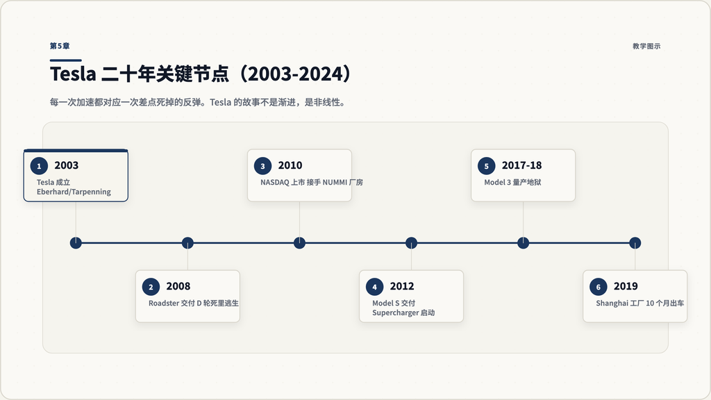

第5章：Tesla 2003-2024 关键节点

**图 5.1：Tesla 二十年关键产品和工厂节点。每一个加速点都对应一次”差点死掉”的反弹——2008 D 轮、2012 Model S、2018 Model 3 量产地狱、2019 Shanghai 速度。**

### 5.7 BD 对话的回收点

第一，Tesla 不是一家”汽车公司”——它是一家”垂直整合的能源 + 数据 + 车辆制造”公司。它自己设计芯片、自己造电池、自己开发软件、自己建充电网络、自己卖车（绕过经销商）、自己融资。这套垂直整合是 Tesla 真正的护城河，也是 Big 3 学不动的部分（因为 Big 3 被经销商法、UAW 合约、品牌历史包袱卡死）。

第二，对中国 EV 厂家进北美，Tesla 是参照系。你的产品参数、品牌定位、销售模型，都会被 Inside EV / Electrek / Cox Automotive 拿去跟 Model Y 比。理解 Tesla 的销售/服务/充电三件套是 BD 对话的起点。

第三，2024-2025 年 Tesla 在美国市场份额从约 49% 跌到 46%，是 EV 行业从”Tesla 独占”进入”多品牌竞争”的转折点。这是中国 EV 进入北美最好的 5 年窗口——市场结构已经准备好接受第二选择，问题只在于”哪个第二选择”被允许进来。

### 5.8 章末检查点

> “Tesla 在 2008 年差一周就破产。如果当时它倒了，今天的电动车行业会是什么样？”

提示：电动车技术本身还会存在（日产 Leaf 2010 年量产，没有 Tesla 也会有），但**电动车作为”高级、高利润、值得追求”的品牌定位**几乎肯定会缺席。市场会被定位成”廉价小型代步工具”——一个完全不同的故事。Tesla 把电动车的品牌升级到豪华车这件事，是它最大的战略遗产。

## 第6章 中国 EV 反超：BYD、宁德时代和”新势力”

### 6.1 2024 年的数字翻盘

先把 2024 年的几个关键数字放在你面前，记住它们：

- **全球纯电（BEV）销量第一：Tesla（约 179 万台）；第二：BYD（约 176 万台）**
- **如果加上插混（PHEV），BYD 总新能源销量约 427 万台，几乎是 Tesla 的 2.4 倍**
- **全球动力电池市场份额：宁德时代 37.9%、BYD 17.2%、LG 新能源 10.7%、SK On 4.7%、松下 4.0%、三星 SDI 3.0%**——前三名都是中国 + 韩国，日本/欧美完全缺席
- **中国 2024 年新能源乘用车销量约 1100 万台，渗透率超 50%**——意味着中国一半新车是电动或插混

这些数字告诉你一件事：电动车产业的全球中心已经在中国，不是即将在中国。

但理解”中国 EV”不能笼统看。这是一个分层市场。

### 6.2 BYD：曾经造电池的电池厂

BYD 1995 年由王传福成立，最初是手机电池厂——给摩托罗拉、诺基亚做锂离子电池。2003 年收购西安秦川汽车进入造车。

BYD 的核心优势从一开始就是**垂直整合的电池**。今天 BYD 自己设计、自己造刀片电池（LFP 路线），自己造电机、自己造控制器、自己造车身。这种垂直整合在中国 EV 厂家里独此一家——其他厂家电池要么靠宁德时代、要么靠中航锂电。

2020 年 BYD 推出”刀片电池”——一种 LFP 电池的新封装形式，能量密度接近 NMC，但安全性更好、成本更低。这是 BYD 的技术节点。

2022 年 BYD 宣布停止纯燃油车生产——这是全球第一家这样做的传统车厂（理解：BYD 在产业语境下被算作”传统车厂”，不是”新势力”）。

2024 年 BYD 海外销量约 41 万台——主要在东南亚、拉美、欧洲、澳新。北美几乎为零（因为关税壁垒，第 11/13 章会讲）。

### 6.3 宁德时代：从来不卖整车，但站在所有车厂的供应链中央

宁德时代（CATL）2011 年从 ATL（新能源科技）分拆，2018 年深圳上市，2022 年市值一度突破 1 万亿人民币。

宁德时代不做整车。它做电池、模组、Pack——卖给 Tesla、BMW、Mercedes、Honda、Stellantis、福特、Volvo、蔚来、小鹏、理想、小米。几乎所有非 BYD / 非 LG / 非松下系的车厂，电池都来自宁德时代。

2024 年宁德时代全球动力电池市场份额 37.9%——第二名 BYD（17.2%）和它中间还有一个”小行星带”距离。

宁德时代的另一条线是储能（ESS）——电网级储能电池。这是 EV 之外被低估的增量市场。储能电池技术要求比 EV 更高（循环次数 5000+ vs EV 的 1500+），单价更高。

宁德时代是中国 EV 出海的真正”地基”。一台 BMW iX、一台 Mercedes EQS、一台福特 Mustang Mach-E，电芯几乎都来自宁德。所以”中国 EV 出海北美”这件事，已经发生——只是发生在电池层，不在整车层。

### 6.4 “新势力”四家：蔚来、小鹏、理想、华为系（含小米）

中国 EV 里”新势力”指 2014-2015 年前后由互联网背景的人创立的纯电动车品牌：

**蔚来（NIO）：** 2014 创立，李斌团队。主打高端 SUV，使用”换电”模式（不充电，开到换电站直接换一块电池）。2024 年交付约 22 万台。最大特点是用户社区运营——“用户来开”是它的口号。换电网络在中国已建超过 3000 座，海外（欧洲）几十座。

**小鹏（XPeng）：** 2014 创立，何小鹏团队。主打中端轿车 + SUV，强项是智能驾驶（XNGP 系统）。2024 年交付约 19 万台。2024 年与大众战略合作——大众基于小鹏 G9 平台开发欧洲产品，这是中德产业关系的标志性事件。

**理想（Li Auto）：** 2015 创立，李想团队。主打增程式 SUV（EREV）——电动车带一台小汽油发动机做充电宝。这条路线在中国家庭市场极其成功，因为它解决了”续航焦虑”和”充电桩稀缺”两个真实问题。2024 年交付约 50 万台——是新势力里销量第一的。

**华为系（含小米）：** 华为不直接造车，但通过 HI（Huawei Inside）和”鸿蒙智行”模式深度参与多家品牌——问界（赛力斯）、智界（奇瑞）、享界（北汽）、尊界（江淮）。问界 M9 2024 年成为中国 50 万人民币以上 SUV 销量第一。 小米 2024 年 3 月推出 SU7，是雷军的”用十年时间认真造一台车”。2024 年小米全年交付约 13 万台，2025 年全年目标曾喊到 30 万台以上，但季度数据波动较大，本手册不引用季度具体数。需要说明：小米的销售模式（直营 + APP + 苹果式发布会）是中国新势力里最像 Tesla 的一家。

### 6.5 这四家之间的关系：竞争 + 合作

2024 年 12 月，蔚来、小鹏、理想、小米四家宣布充电网络互联——蔚来 14000 个充电桩、小鹏 9000 个、理想 6000 个，互相向小米用户开放。这件事在西方车厂之间几乎不可能发生（看美国 OEM 在 NACS 之前的混战，第 8 章）。

中国新势力为什么能合作？两个原因：

第一，它们的对手不是彼此——是 BYD、是 Tesla、是传统合资品牌。 第二，它们都在亏钱或薄利状态，没有一家有资本独自烧充电网络。合作建网比单干便宜。

但合作不是没有摩擦。2025 年 4 月有中国车业分析师公开说”蔚来、小鹏、理想三家三年内独立存活概率为零”——这是一家分析师的观点，不是事实。值得在 BD 对话里知道这个说法存在，但不要把它当结论引用。

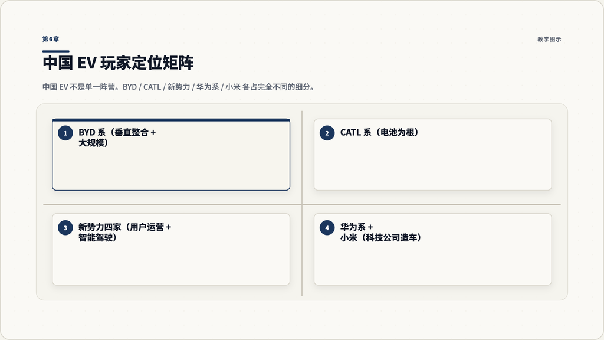

第6章：中国 EV 玩家定位矩阵

### 6.6 BD 对话的回收点

第一，跟中国 EV 厂家对话第一步：**先判断这是 BYD 系（垂直整合 + 大规模）、还是宁德时代系（电池为根 + 客户即对手）、还是新势力系（用户运营 + 智能驾驶 + 烧钱换增长）。** 这三类逻辑完全不同，不能用同一套话术对接。

第二，BYD 进北美最大的瓶颈不是技术——是它的整车不能直接卖到美国（100% 关税）。但 BYD 的电池业务、商用车业务、储能业务可以走另一条路（详见第 10 章和第 13 章）。

第三，宁德时代已经在北美。福特正在密歇根用宁德时代的技术授权建电池厂（LRS 模式——License, Royalty, Services；福特拥有工厂，宁德时代提供技术和管理）。这个模式可能是未来 5 年中国电池厂进入北美的主流模式。

### 6.7 章末检查点

> “在 2024 年，全球纯电销量 BYD 比 Tesla 少约 3 万台，但 BYD 的总新能源销量是 Tesla 的 2.4 倍。这两个数字告诉你什么？”

提示：BYD 的核心市场是中国家庭——选择”插混 + 增程”路线，不强求纯电。Tesla 是纯电品牌。两种逻辑根本不同——前者解决”现在就替代燃油车”，后者解决”长期电动化”。BD 对话里如果有人说”BYD 超过 Tesla 了”，需要分清是哪一个数字——BEV 还是 NEV，因为含义完全不同。

## 第7章 电池供应链：锂矿、电芯、Pack — 谁掌握了什么

### 7.1 一台电动车里 30% 的价值在电池

一台中端电动车的物料成本（BOM）中，电池组（battery pack）通常占 25-35%。这是燃油车没有的成本结构——一台燃油车里发动机占 BOM 的 10-15%。

这意味着：**电动车产业的财富集中度在电池**，不在整车。整车厂可能赚 5-8% 毛利，电池厂可能赚 20-25%。

理解电池供应链对 BD 工作的意义：你跟任何一家 OEM 谈”中国 EV 进北美”，对方第一反应不是”这台车好不好”，而是”它的电池从哪来？符不符合 IRA 的 FEOC 规则？经不经得起 UFLPA 拦截？”

电池供应链分四层。每一层在地理上和企业上有不同的集中度。

### 7.2 第一层：矿——锂、镍、钴、石墨

**锂（lithium）**：电池的核心金属。2024 年全球锂矿产量约 24 万吨碳酸锂当量（USGS 数据，按碳酸锂当量计）。主要产地：

- 澳大利亚：约 8.8 万吨（硬岩 spodumene）
- 智利：约 4.9 万吨（盐湖卤水）
- 中国：约 4.1 万吨
- 阿根廷：约 1.8 万吨

澳大利亚是世界第一锂矿产国。但澳大利亚的锂大部分出口到中国加工——这是关键。

**镍（nickel）**：高镍三元（NMC）电池需要镍。印尼、菲律宾、俄罗斯是前三大产地。印尼禁止原矿出口、强制本地加工，2020 年后改变全球镍供应格局。

**钴（cobalt）**：刚果（DRC）一家占全球约 70%。钴是 NMC 电池里成本最高的金属，2017-2018 钴价暴涨直接推动电池产业从 NMC 转向 LFP（磷酸铁锂，不含钴）。

**石墨（graphite）**：电池负极材料。中国一国占全球天然石墨产量的 65% 以上，且占全球加工市场 90%+。

### 7.3 第二层：加工——盐湖到电池级原料

矿出来还不能直接做电池。锂矿要变成电池级碳酸锂或氢氧化锂；镍矿要变成硫酸镍；钴要变成硫酸钴。这一步叫”精炼”或”加工”。

**这一层 65% 集中在中国**。中国不是世界第一锂矿产国（澳大利亚才是），但**世界 60-70% 的电池级锂化合物在中国加工**。镍硫酸盐、钴硫酸盐、石墨负极，加工集中度更高（70-90%）。

这是为什么”中国控制电池”这句话不是夸张。表面看是矿——其实是加工。哪怕南美和澳洲挖出矿，绝大部分还是要进中国加工厂才能变成电池级原料。

### 7.4 第三层：电芯（cell）

电池级原料变成正极材料（cathode）、负极材料（anode）、电解液、隔膜，然后组装成电芯。

电芯生产前六大公司（2024 数据）：

| 公司 | 国家 | 全球份额 |
| --- | --- | --- |
| 宁德时代 CATL | 中国 | 37.9% |
| BYD | 中国 | 17.2% |
| LG 新能源 | 韩国 | 10.7% |
| SK On | 韩国 | 4.7% |
| 松下 Panasonic | 日本 | 4.0% |
| 三星 SDI | 韩国 | 3.0% |

中国 + 韩国 = 约 70%；中国本国占约 55%。日本（松下）只剩 4%，美国/欧洲本土自有电芯产能基本可忽略。

这个集中度是电池工业的关键事实。即使是 Tesla，自己宣称要做 4680 电芯，目前为止大部分电芯仍由松下（Nevada 工厂）和宁德时代（中国）提供。

### 7.5 第四层：Pack 集成

电芯组成 Pack，Pack 装进车。Pack 的设计（cell-to-pack、电池管理系统、热管理）和电芯本身一样重要。

Pack 这一层的集中度低于电芯——很多 OEM 自己做 Pack 集成（包括 Tesla、BYD、福特、GM 等）。这是 OEM 留给自己的”附加值”层。

但 Pack 也分两路：

- **BYD 的刀片电池 + CTB（电池到车身）**：把电芯封装直接做成车身底盘的一部分，大幅减重和降低成本
- **特斯拉 4680 + 结构电池组（structural battery pack）**：类似思路，把电池组当成车架结构件

这一层的技术差异决定续航 / 重量 / 成本——是产品差异化的关键。

### 7.6 第五层（隐形）：回收

电池有 8-15 年使用寿命。2030 年后大批 EV 电池将退役——回收链路在哪？

2025 年回收产业刚起步，主要玩家：

- **美国：** Redwood Materials（J.B. Straubel 创立，Tesla 前 CTO）、Li-Cycle（加拿大上市，2025 年陷入财务危机）
- **欧洲：** Northvolt（瑞典，2024 年破产保护、2025 重组）
- **中国：** 格林美、华友钴业、邦普（宁德时代旗下）

回收提供了一个绕过原矿政治的路径——锂、镍、钴可以从废旧电池里提取回来。但 2025 年的产能远远跟不上未来 5-10 年退役 EV 的规模。

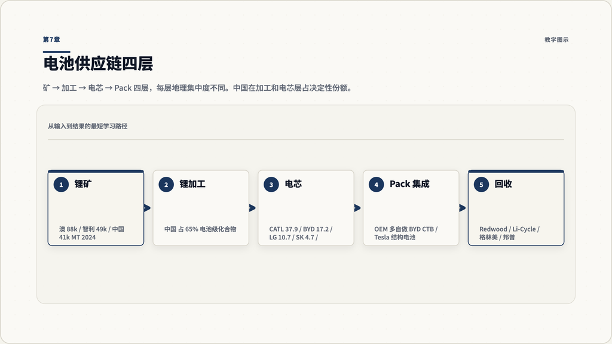

第7章：电池供应链四层

**图 7.1：从锂矿到电芯，每一层的地理集中度都不同。中国不是矿的第一名，但在”加工”和”电芯”两层占决定性份额。**

### 7.7 BD 对话的回收点

第一，“美国想脱离中国电池”这件事，在 2030 年前几乎不可能完成。原因不是产能不够——是矿的加工。要在北美建一套完整的从矿到电芯的加工链，需要 5-10 年和数百亿美元投入，且要打通环保审批、社区接受、技术工人培训等几十道关。

第二，IRA 的 FEOC（外国受关注实体）规则——禁止使用中国、俄罗斯、朝鲜、伊朗的电池组件——本质上是在强迫美国 OEM 选边站。福特跟宁德时代用 LRS 模式合作（技术授权 + 服务，但宁德时代不持股），就是为了绕开 FEOC 的字面要求。这种 LRS 模式是中国电池厂进入北美的”灰色通道”。

第三，回收产业是未来 5-10 年最被低估的 EV 增长点。如果你在加拿大做 EV BD，关注 Li-Cycle、Redwood Materials、以及加拿大本土在矿端的新项目（魁北克 Saint-Augustin 锂矿、Nemaska Lithium），这些是加拿大有结构性优势的环节。

### 7.8 章末检查点

> “为什么澳大利亚是世界第一锂矿产国，但’锂的话语权’依然在中国？”

提示：因为加工层和电芯层都在中国。矿是上游原料，但价值真正被锁定在加工和电芯两层。澳大利亚出口矿赚的钱远少于中国加工后再卖电芯赚的钱。这个”上游不等于话语权”的逻辑，是理解电池供应链最重要的一句话。

## 第8章 充电网络的洗牌：NACS 怎么颠覆 CCS

### 8.1 2022 年之前，美国充电是一团乱

2022 年之前美国电动车充电插口有三套并行的标准：

- **CHAdeMO**：日系（日产 Leaf、三菱 Outlander 等）
- **CCS Combo 1**：美系 + 欧系 + 韩系（Ford Mustang Mach-E、GM Bolt、VW ID.4、Hyundai Ioniq 5 等）
- **NACS / Tesla 标准**：Tesla 专属，最早叫”Tesla connector”

充电运营商也是一团：Electrify America（大众柴油门事件赔款建立的网络）、ChargePoint（最大第三方）、EVgo（独立）、Tesla Supercharger（专属）。一个 Ford Mustang Mach-E 车主想长途出行，要装一个 Plug Share 之类的 app 来找 CCS 桩。一个 Tesla 车主只需打开车上地图就行。

这种碎片化是 Tesla 长期的隐形护城河。

### 8.2 2023 年 5 月：Ford 投降，剧本翻盘

2023 年 5 月 25 日，Ford 宣布从 2025 年起，新车采用 Tesla NACS 接口；2024 年起，现有 Ford 电动车通过转接头接入 Tesla Supercharger 网络。

这是行业地震。一家 Big 3 公司，主动放弃自家标准，加入对手的网络。

到 2024 年中，几乎所有北美卖车的非 Tesla OEM 都签了 NACS 协议：现代起亚、丰田、本田、日产、Mercedes、BMW、VW、Stellantis、Polestar、Lucid、Mazda、Subaru、Nissan……

### 8.3 SAE J3400：从专属到行业标准

2023 年 6 月 SAE International 启动 NACS 标准化进程。2024 年 9 月，SAE J3400 标准正式发布——NACS 从 Tesla 专属变成行业开放标准。

意义：任何充电运营商可以做 J3400 接口的桩，不需要 Tesla 授权；任何 OEM 可以做 J3400 接口的车，不需要 Tesla 授权。NACS 在事实和形式上都成了北美充电标准。

CCS 在新车上还会持续一段时间（Stellantis 2024-2025 一些车型仍是 CCS），但 2025 年以后新车型几乎都转 NACS / J3400。

### 8.4 充电运营商的格局变化

NACS 统一带来一个连锁效应：第三方充电运营商面临选择——继续做 CCS 桩，还是转 J3400？

主要运营商规模（2024-2025 数据）：

- **Tesla Supercharger**：北美约 2800+ 站，5 万+ 桩；2023 年起向非 Tesla 车开放（首先是 Ford，然后扩散）
- **Electrify America**：约 1000 站，4500+ 桩；大众柴油门赔款建立，现已成为 CCS 网络第一名（转 J3400 中）
- **EVgo**：约 1100 站，3680 桩（2024 Q3 数据）；纳斯达克上市，从 DOE 拿到 12.5 亿美元贷款扩张
- **ChargePoint**：场站数最多（含 Level 2 慢充），但快充网络规模有限

Tesla Supercharger 的”开放”是渐进的——先 Ford 车型，然后 GM、Rivian……每个 OEM 都要单独签协议，单独适配车端软件。这意味着 Tesla 在事实上仍然控制着开放的节奏和优先级。

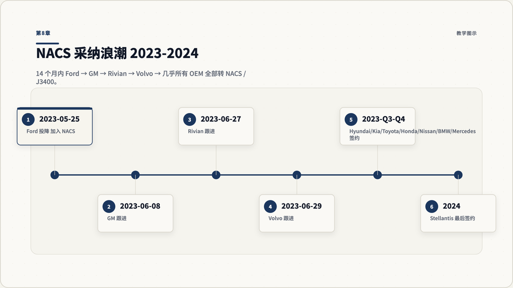

第8章：NACS 采纳浪潮 2023-2024

### 8.5 加拿大充电格局

加拿大充电网络密度远低于美国。2024 年加拿大快充桩约 1.2 万个，主要集中在 BC、安大略、魁北克三省。东部三省（PEI、NS、NB）和北部地区基础设施严重不足。

加拿大主要玩家： - **Tesla Supercharger 加拿大网络**：约 100+ 站 - **Petro-Canada Electric Highway**：约 50 站，覆盖跨加公路（TransCanada Highway）核心节点 - **Flo（加拿大本土）**：以 Level 2 桩为主，市占率高，但快充少 - **Electrify Canada（大众系）**：约 50 站

加拿大联邦在 2024 推出充电基础设施补贴（NRCan Zero Emission Vehicle Infrastructure Program），目标 2027 年 33000 个快充桩。这个目标 vs 现状有巨大缺口——是 EV 基础设施 BD 的机会窗口。

### 8.6 BD 对话的回收点

第一，**充电插口的标准化已经发生，剩下的是快慢问题**。如果你跟中国 EV 厂家谈进入北美，2026 起新车型必须做 NACS / J3400 接口——这不是选择，是市场入场门票。

第二，加拿大快充网络密度远不够 EV 渗透率上升的需要。这对充电运营商是机会、对 OEM 是合作切入点。如果一家中国 EV 厂家承诺”和加拿大本土运营商共建 500 个 NACS 站”——这是一张比单纯卖车更受欢迎的入场券。

第三，Tesla 在 2024-2025 大幅缩减 Supercharger 团队（裁员事件多次发生）——这给了第三方运营商扩张窗口。EVgo（拿到 DOE 12.5 亿贷款）和 Electrify America 是当下最有扩张能力的两家。和它们的合作可能比和 Tesla 网络合作更稳定。

### 8.7 章末检查点

> “为什么 Ford 在 2023 年 5 月这个时间点宣布加入 NACS？早一年或晚一年会怎样？”

提示：早一年 Tesla 拒绝开放、Ford 也没准备好；晚一年 Mustang Mach-E 已经在客户体验上严重落后。2023 年是 Tesla 充电网络规模已经压倒性领先（5 万+ 桩 vs CCS 网络 1 万+），同时 Tesla 自己也需要新的收入来源（向其他 OEM 卖网络使用权）。两边的需求在那个时间点对齐。

## 第9章 OEM-Dealer 法律壁垒：Tesla 在 50 个州各打一场仗

### 9.1 美国 dealer franchise law 的来历

美国大多数州有一套叫”dealer franchise law”的法律。它规定：汽车厂不能直接卖车给消费者，必须通过独立的经销商（dealership）。

这不是 21 世纪发明的——它是 1950 年代 GM、Ford、Chrysler 跟 dealer 之间力量博弈的产物。当时 Big 3 厂家强势压价，dealer 通过游说州议会立法保护自己，要求 OEM 必须经第三方 dealer 销售，且 dealer 拿到特许权后受保护（不能轻易被取消）。

### 9.2 Tesla 的州际游击战

Tesla 拒绝走 dealer 模式。它选择直营——自己的销售门店、自己的服务中心、官网直接下单。

这立刻把它和 50 个州的 dealer franchise law 撞上。Tesla 不得不在每个州各打一仗：

- **明确允许直营的州**（约 25-30 个）：包括加州、纽约、马萨诸塞、华盛顿等
- **完全禁止直营的州**（约 5-10 个）：包括德州、康涅狄格、犹他、阿拉巴马等
- **混合 / 数量限制 / 法律灰色地带**（其余）：例如允许有限数量门店（密歇根曾经禁过，2014 年立法明文禁止）

德州是最典型的案例。Tesla 在德州造车（Gigafactory Texas 在 Austin），但德州法律禁止 Tesla 在德州本地直接卖车给消费者——德州买家只能从其他州下单或绕开当地法规。

### 9.3 Tesla 的解法

Tesla 在受限州的解法分三层：

**第一层：技术性绕过。** “Gallery”门店——只展示、不销售。消费者可以来看车、试驾，但购买要通过其他州的网站完成。 **第二层：服务中心独立。** 即使禁止销售，服务中心通常被允许——所以 Tesla 在受限州仍有维修网络。 **第三层：法律游说。** 持续推动州立法改革。每年都有几个州法案试图开放或限制直营。

这套游击战是 Tesla 真正的”看不见”成本——14 年下来花了大量法律和游说预算。但因为 Tesla 不依赖经销商网络，它的售后毛利和定价控制都比 OEM 强。

### 9.4 中国 EV 进美国会撞上同样的墙

这是 BD 对话里的核心命题：

如果 BYD、蔚来、小鹏想直营进美国（绕过 dealer），它们要重打 Tesla 14 年前的州际官司——而且每个州 dealer 协会都会因为 Tesla 的前车之鉴，立法更严。

如果它们选择 dealer 模式，问题更大：

- 没有现成 dealer 愿意接手一个零品牌、零售后体系的新进入者
- Dealer 要求保证金、独占协议、毛利保障
- 售后服务体系要 dealer 自己投入培训（中国 EV 厂家初期没能力支撑）

历史上一家成功”从零建 dealer 网络”的非美系厂家——韩国现代——花了 30 年（1986 年首次进美国到 2010 年代真正主流）。

### 9.5 加拿大的差别：温和很多

加拿大的法律环境跟美国差别巨大：

**加拿大没有全国统一的 dealer franchise 法**。各省的法规不同： - **安大略**：有 Motor Vehicle Dealers Act，但允许 OEM 直营（Tesla 在多伦多有直营门店和服务中心） - **魁北克**：法律相对宽松，Tesla 直营无障碍 - **BC**：允许直营，BC EV 销售许可比美国宽松

Tesla 在加拿大没有打过类似美国那种州际官司。这是加拿大对中国 EV 进入是更友好通道的一个事实基础。

但加拿大有另一个独特限制——**新车前 12 个月的”灰色市场”问题**。如果一台中国 EV 通过墨西哥或别的渠道进入加拿大，海关有权扣留判定。需要正规进口认证（Transport Canada Type Approval）。

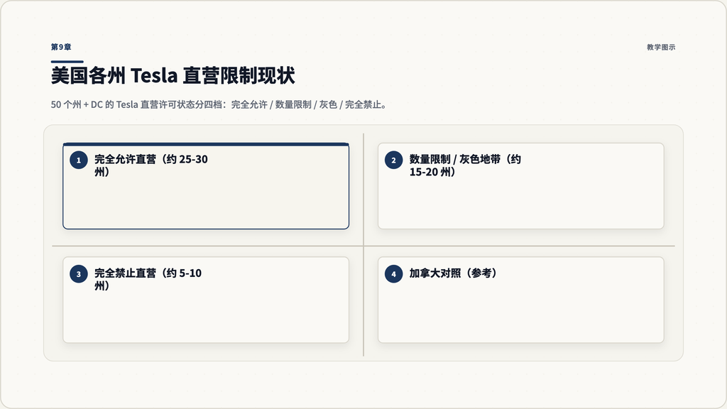

第9章：美国各州 Tesla 直营限制现状

**图 9.1：美国 50 个州 + 华盛顿特区的 Tesla 直营许可状态。德州、康涅狄格等几个州完全禁止；密歇根 2014 年立法禁止；其他州有限制或允许。**

### 9.6 BD 对话的回收点

第一，**Dealer franchise law 是中国 EV 进美国最大的”隐形”壁垒**——比 100% 关税还难。关税可以通过墨西哥工厂（USMCA 北美自由贸易区）部分解决；dealer 法律是州一级的，每个州要单独打。

第二，加拿大不是这个问题。中国 EV 在加拿大可以直营，可以建自己的服务中心。这是加拿大相对美国的关键差异。当你跟客户讨论”北美战略”，不要把美国和加拿大混为一谈——它们是两个监管语境。

第三，dealer 网络的真正价值不是销售（电商可以替代），而是**售后服务网络**。EV 不需要发动机维修，但需要电池诊断、软件升级（OTA 之外的物理维修）、事故维修。任何中国 EV 想在加拿大做规模，必须先想清楚售后网络。可能的解决路径：跟现有加拿大 dealer（Honda / Hyundai dealer 等）合作，让他们做 EV 售后授权服务点。

### 9.7 章末检查点

> “为什么 Tesla 花 14 年在美国跟各州打 dealer 官司，没有选择 ‘dealer 妥协路径’？”

提示：因为 dealer 模式会破坏 Tesla 的定价、品牌、服务三条护城河。Tesla 直营 = 直接掌握客户数据、统一价格（无议价）、统一服务体验。一旦走 dealer，这三条全部稀释。对中国 EV 来说，这是一个战略选择：要直营的高毛利和品牌一致性，还是要 dealer 的快速铺开？答案因厂家不同——比亚迪可能选 dealer 快速铺开，蔚来可能选直营保品牌一致性。

## 第10章 美国的三道墙：IRA、Section 301、UFLPA

### 10.1 三道墙不是一道

美国限制中国 EV 进美国，不是用一道墙——是用三道结构不同的墙，叠加形成一个”几乎不可能”的边界。

理解这三道墙是 BD 对话最重要的”硬通货”。每个 OEM 高管、每个咨询公司、每个政府关系经理都在反复使用这三个词。如果你混淆 IRA 和 Section 301，对方会立刻判定你不是行家。

三道墙的功能分工：

| 政策 | 性质 | 对中国 EV 的具体作用 |
| --- | --- | --- |
| **Section 301（关税）** | 贸易关税壁垒 | 100% 关税让进口几乎不可能 |
| **IRA 30D（补贴）** | 财政补贴 + FEOC 排除 | 即使能进口，也拿不到 $7,500 税收抵免 |
| **UFLPA（海关执法）** | 强制劳动法 + 海关拦截 | 海关可扣留任何”涉嫌新疆”的电池或部件 |

### 10.2 第一道墙：Section 301 / 100% 关税

Section 301 是 1974 年贸易法的一个条款，授权 USTR（美国贸易代表办公室）对”不公平贸易行为”采取关税报复。

2024 年 5 月，拜登政府宣布将中国 EV 关税从 25% 提高到 100%。9 月 12 日 USTR 发布最终修改条款，9 月 27 日生效。

100% 关税意味着：一台中国 EV 出厂价 3 万美元，进美国时关税 3 万美元，到岸成本 6 万——加上 dealer 利润和州税，最终消费者价 7 万。这个价格让任何中国 EV 在美国市场失去竞争力。

但 Section 301 有几个**漏洞**：

- **不适用于在美国本土生产的车**（USMCA 区域 = 美国 + 墨西哥 + 加拿大；本地生产可免关税）
- **不适用于电池部件**（部件关税独立，且有自己的关税表，2024-2025 部件关税大幅上调）
- **不适用于商用车**（卡车、巴士属于另一个 HTS 关税类别）

2024-2025 年中国电池关税从 7.5% 提高到 25%，部分关键部件（如负极材料）税率也提升。这意味着即使是和 OEM 合作的电池工厂（如福特跟宁德时代的 LRS 项目），关税也在上涨。

### 10.3 第二道墙：IRA 30D + FEOC

IRA（Inflation Reduction Act）2022 年 8 月签署。它的核心电动车条款是 30D——给新能源车买家 $7,500 联邦税收抵免。

这 $7,500 分成两半：

- **$3,750 关键矿物（critical minerals）**：电池里 50%+（逐年提升）的关键矿物必须来自美国或自由贸易伙伴国
- **$3,750 电池组件（battery components）**：电池组件 60%+（逐年提升）必须在北美生产

2024 年 5 月美国财政部发布 30D 最终规则——**FEOC（Foreign Entity of Concern）**条款细化：任何”由中国、俄罗斯、朝鲜、伊朗控制”的实体参与的电池组件或关键矿物，都不算合规。“控制”定义包括 25%+ 股份或董事会任命权。

FEOC 的实际效果：

- 一台用了中国电芯的电动车，**完全失去** $7,500 资格
- 一台用了中国锂加工但电芯在韩国的车，**部分失去**资格（关键矿物那一半）
- 福特用宁德时代技术授权（LRS 模式，无股权）建电池厂，**理论上仍然合规**——但这是 IRS 的灰色地带，2025 年仍在解释中

需要说明：30D 的命运在 2025 年大变。2025 年 7 月通过的 OBBBA（One Big Beautiful Bill Act）规定 30D 在 2025 年 9 月 30 日终止——比原定 2032 提前 7 年。这意味着 2025 年 10 月起，任何买 EV 的美国消费者都不再有 $7,500 联邦抵免。这件事大幅改变了北美 EV 的成本-需求曲线，对中国 EV 反而是”美国本土 EV 优势减弱”的窗口（但中国 EV 的关税壁垒不变，所以这个窗口对中国整车厂家没用，对中国电池/零部件厂家则可能利好）。

### 10.4 第三道墙：UFLPA

UFLPA（Uyghur Forced Labor Prevention Act）2021 年 12 月签署。它的核心机制：

**任何”产自新疆、或与新疆相关公司有关联”的商品，被默认存在强迫劳动嫌疑，海关可直接扣留**——除非进口方能证明商品没有强迫劳动参与。这是”有罪推定”，不是”无罪推定”。

UFLPA 的”Entity List”是 CBP（海关边境保护局）和 DHS（国土安全部）联合发布的关注实体名单。截至 2024 年 11 月底，名单上 107 家公司，其中 29 家是 2024 年 11 月 25 日新增的。

EV 行业被 UFLPA 影响的具体环节：

- **多晶硅 / 光伏**：新疆多晶硅产能占全球约 35%，光伏组件大量被扣
- **铝**：新疆铝厂被列入 UFLPA Entity List，特斯拉 / 福特 / GM 等 OEM 都被 CBP 扣过铝制部件
- **棉花**：用于汽车内饰
- **锂 / 镍**：尚未被广泛涉及，但风险存在

CBP 2024 年发布的执法报告显示，汽车行业已多次被扣货物——既包括中国厂家的，也包括美国 / 韩国 / 欧洲厂家供应链里有新疆来源的产品。

### 10.5 三道墙叠加的实际效果

把三道墙叠在一起：

1. 中国整车 100% 关税 → 直接出口不可能
2. 即使绕道（如墨西哥 USMCA）解决了关税，电池组件不合规 → 失去 IRA 补贴 → 价格竞争力不够
3. 即使补贴问题解决，UFLPA 拦截 → 货物可能在海关一锁就是几个月

任何一条单独看，都有可能绕过；三条叠加，对中国整车厂家基本是死锁。

但对中国零部件/电池厂家有空间：

- **零部件不在 30D 直接管理范围**（30D 管整车买家）
- **如果通过 LRS 模式（技术授权 + 美国本土生产）合作，可能合规**
- **某些细分品类（电芯材料、负极、隔膜）UFLPA 风险较低**

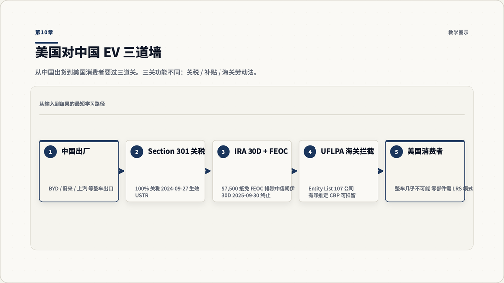

第10章：美国对中国 EV 三道墙

**图 10.1：从中国出货到美国消费者手里要过三道关。第一道关税让进口经济性塌方；第二道补贴+FEOC 让本地化生产也补不上；第三道 UFLPA 让供应链不能含新疆敏感环节。**

### 10.6 BD 对话的回收点

第一，**永远不要把”关税”和”IRA”混为一谈**。关税是贸易壁垒（USTR 管），IRA 是补贴（财政部管），UFLPA 是劳动法（CBP / DHS 管）。三个部门、三套程序、三种豁免路径。在 BD 对话里把它们清楚分开，立刻可以提升专业度。

第二，**30D 在 2025 年 9 月 30 日终止**——这是 2025 年最大的政策变化。任何 2024 年之前的”IRA 攻略”必须重新评估。如果你的客户引用 2024 年的资料讨论 30D 抵免，你应该立刻提醒”30D 已废止，现在适用的是关税 + 反规避调查 + UFLPA”。

第三，加拿大不在 IRA 30D 的管辖范围（加拿大是 USMCA 国家，但 30D 是美国国内补贴），但加拿大跟美国在关税和 UFLPA 类似政策（Canada 的 Forced Labour Act 调查框架）上保持基本同步。第 11 章详细讲加拿大的差异。

### 10.7 章末检查点

> “如果你是 BYD 海外业务负责人，看着这三道墙，你的最优 5 年策略是什么？”

## 第11章 加拿大的位置：跟美国跑还是自走路

### 11.1 加拿大 EV 市场的基础事实

把 2024 年加拿大几个数字放在你面前：

- **加拿大全国 2024 年 EV 渗透率约 15%**（含 BEV + PHEV）
- **魁北克省 EV 渗透率约 33%**（远高于全国平均，受 Quebec 补贴 + 法律强推动）
- **BC 省约 23%**
- **安大略约 8%**
- **平原省份（阿尔伯塔、萨斯喀彻温）EV 渗透率低于全国一半**

加拿大 EV 市场最大的特点是**地理碎片化 + 政策分层**。联邦政策、省政策、市政策叠加。同一台车在 BC 和阿尔伯塔的补贴差异可以达到上万加元。

### 11.2 加拿大的政策层级

理解加拿大 EV 政策要分三层：

**第一层：联邦** - iZEV 联邦补贴 ($5,000 per BEV)：2024 年补贴预算用尽暂停，2025 年是否续期不确定 - ZEV mandate（联邦零排放车销售强制比例）：原计划 2026 年新车销售 20% ZEV，2030 年 60%，2035 年 100%——但 2025 年部分省份和厂家强烈反对后政策有动摇 - 充电桩补贴（ZEVIP）：每个快充桩 $50,000-$75,000 上限补贴 - 100% 中国 EV 关税（2024 年 8 月 27 日生效）—— 跟美国 USTR Section 301 同步

**第二层：省级** - 魁北克：本地 ZEV 补贴 + 强制销售比例（领先全加） - BC：ZEV mandate（原本 100% by 2035，2025 年降为 75% by 2035）+ 省级补贴 - 安大略：2018 年取消省级 EV 补贴，但工业政策（电池厂、合作建厂）力度大 - 平原省：基本无补贴

**第三层：市政 / 地方** - 多伦多、温哥华、蒙特利尔有充电桩补贴和停车优惠 - 私人物业充电安装的法规各市不同（condo 安装是 BD 痛点）

### 11.3 加拿大对中国 EV 的官方态度

2024 年 8 月 27 日，加拿大政府宣布对中国制造的 EV 加征 100% 附加关税——跟美国 9 月 27 日的 USTR 行动几乎同步。

这是一个意外的、强硬的姿态——加拿大此前一直被认为更”自由贸易倾向”。但 2024 年是大选前夕，工业政策（保护安大略电池厂、保护魁北克汽车零部件工业）取代了开放姿态。

2026 年 3 月（详细日期截至本手册截止时一些来源仍在校对中），加拿大宣布对中国 EV 进口”开口子”：允许 49,000 辆中国制造 EV 进入加拿大，关税降为 6.1%。这个配额相当于加拿大 2024 年 EV 销售总量的约 20%——是一个相当大的数字。

这件事的解读：

一是加拿大政府希望刺激 EV 普及（联邦 ZEV mandate 还在），但本土 OEM（GM 加拿大、Ford 加拿大）没有足够便宜的 EV——配额是变相的”开闸门”。

二是加拿大不想完全跟美国保持 100% 同步——这是加拿大保留一定政策独立性的姿态。

三是这 49,000 配额的具体分配机制（哪些厂家、哪些车型）2026 年 5 月仍在政策制定中。这是 BD 对话的”实时窗口”——加拿大本地 BD 工作如果能在这个配额分配上做工作，是直接产业影响。

### 11.4 加拿大本土的电池厂投资潮

2022-2024 年加拿大宣布了多个电池厂投资项目：

- **LG Energy + Stellantis（NextStar Energy）**：加拿大温莎工厂，2025 年起量产，约 50 亿加元投资
- **Honda 加拿大**：宣布加拿大 EV 产业链总投资约 150 亿加元（含电池、整车）
- **Volkswagen / PowerCo**：宣布加拿大圣托马斯电池厂，2027 年量产
- **Northvolt 加拿大**（魁北克）：宣布过 70 亿加元投资，但 Northvolt 2024 年破产保护后，项目命运不明
- **Umicore（比利时电池材料厂）**：金斯顿正极材料厂

这些项目背后的逻辑是：加拿大有完整的电池上游（魁北克锂矿、加拿大本土镍、北部钴）+ 美国汽车产业的供应链需求。加拿大想做”北美电池产业链的关键节点”——既不依赖中国，也补足美国本土的能力短板。

但 2024-2025 多个项目延期或重新评估——主因是美国 IRA 30D 在 2025 年 9 月废止，让”在加拿大建电池厂供美国”的经济性快速下降。这是 BD 工作必须实时跟进的状态。

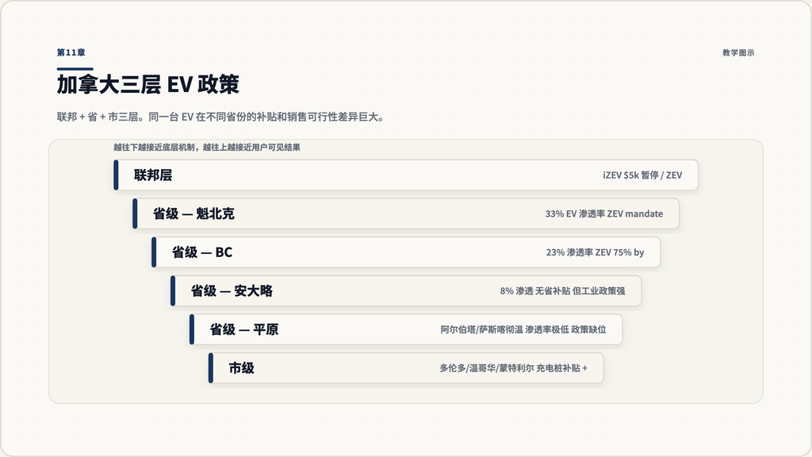

第11章：加拿大三层 EV 政策

**图 11.1：加拿大 EV 政策的联邦 / 省 / 市三层结构。魁北克和 BC 是省级 ZEV 强推驱动，安大略是产业政策驱动，平原省份基本缺位。同一台中国 EV 在不同省份的补贴和销售可行性差异极大。**

### 11.5 BD 对话的回收点

第一，加拿大不是”小一号的美国”。它是一个独立的监管和市场语境。任何把美国 EV 战略直接套到加拿大的客户，都会犯结构性错误。例如美国 dealer franchise law 在加拿大不存在/不严格——这意味着中国 EV 在加拿大可以做直营。

第二，**2026 年的 49,000 辆配额是 5 年级别的窗口**。如果一家中国 EV 厂家拿到这个配额的一部分（即使只有几千台），就建立了北美第一个真实的销售网络、第一个售后体系、第一个客户案例库。从 BD 角度看，这件事的战略意义比销量本身大得多。

第三，加拿大本土的关键决策角色不在 OEM——而在政府间关系和产业政策机构：

- 联邦层：Innovation, Science and Economic Development Canada（ISED）
- 安大略省：Invest Ontario
- 魁北克：Investissement Québec
- 工业商会：Canadian Vehicle Manufacturers’ Association（CVMA，代表 Big 3）；Global Automakers of Canada（GAC，代表丰田 / 本田 / 现代等）

这些机构是 BD 工作的”政府间界面”。如果你想做的是中国 EV 进加拿大 BD，跟这些机构的关系远比跟单个 OEM 的关系重要。

### 11.6 章末检查点

> “为什么加拿大 2024 年 8 月跟美国同步加 100% 关税，但 2026 年 3 月又主动放出 49,000 配额？”

提示：加拿大政府在两个相反方向上同时下注——既保护本土电池/汽车工业（关税），又满足 EV 普及目标和消费者价格压力（配额）。这是小国在大国之间走平衡的典型策略。理解这个张力，你就能预测加拿大未来 2-3 年政策走向：不会完全跟美国，但也不会完全开放中国。

## 第12章 北美 OEM 现状：Ford / GM / Stellantis / Toyota / Hyundai-Kia 谁押什么

### 12.1 五家 OEM 在 EV 上的战略不一样

2025 年的北美 EV 市场份额（仅 EV 部分，非全车型）：

| OEM | 美国 EV 份额 | 主要 EV 车型 | 战略姿态 |
| --- | --- | --- | --- |
| Tesla | 46.2% | Model Y / Model 3 / Model X / Model S / Cybertruck | 收缩、押软件 / FSD |
| GM | 13.2% | Chevy Equinox EV / Blazer EV / Cadillac Lyriq | 暂缓、Ultium 重新评估 |
| Ford | 6.6% | Mustang Mach-E / F-150 Lightning | 大幅缩减、推迟二代平台 |
| Hyundai-Kia | 5.1%（合计） | Ioniq 5/6 / Kia EV6 / EV9 | 持续扩张、欧美双线 |
| Stellantis | < 5% | Jeep Wagoneer S / Recon / 等 | 2025 重启、Chrysler/Jeep 北美追赶 |
| Toyota | < 5% | bZ4X / Lexus RZ | 混动优先、纯电跟跑 |
| Rivian | ~3% | R1S / R1T | 高端 SUV/卡车独立战 |

这个表的核心：**Tesla 一家占 46%，剩下 OEM 在分剩下的 54%**。这是过去三年中国 EV 故事的镜像——一家独大 vs 多家分蛋糕。

### 12.2 GM：Ultium 战略的痛苦调整

GM 2020 年起押注 Ultium 电池平台——一个能用于从轿车到卡车的通用电动平台，目标 2025 年全面铺开。

2024-2025 年 GM 大幅调整 Ultium 步伐：

- 2025 年 1 月，GM 公告全年因 EV 业务录得约 $79 亿美元的特殊费用（含资产减值、产能调整等），并对部分车型计划延期、Ultium 工厂阶段性暂停
- Factory ZERO（Hamtramck，密歇根）2024-2025 多次暂停产线，部分员工调岗或裁员（其中一次单次裁员约 1,200 人）
- 一些原本 2026 量产的车型推迟到 2027 或更晚

GM 的当下姿态：把 EV 产能锁在能赚钱的车型（Equinox EV、Blazer EV、Lyriq）上，砍掉中产 EV 卡车（如 Silverado EV 部分产能）。

### 12.3 Ford：Model e 部门累计亏损

Ford 在 2022 年把电动车业务独立成 Ford Model e。但 Model e 2023、2024 都大幅亏损（每年 50 亿美元以上），2025 年继续亏。

Ford CEO Jim Farley 2024-2025 多次公开重新校准 EV 战略：

- 推迟原计划 2026 的二代 EV 平台
- 砍掉部分 3 排座大型电动 SUV 项目
- 把更多投资重新放到混动（PHEV / HEV）和燃油 F-150 / Bronco
- 跟宁德时代的 Marshall 电池厂（密歇根）规模缩小

但 Ford 在皮卡这个细分市场守住了 F-150 Lightning——这是北美 EV 卡车销量第二（仅次于 Rivian R1T 的高端定位）。

### 12.4 Stellantis：2025 年净亏 226 亿欧元的重启年

Stellantis 2025 全年财报：

- **净亏损约 226 亿欧元**
- **包含约 254 亿欧元一次性减值**（含 EV 平台、燃料电池项目、若干工厂资产）
- **2025 年发布 10 款新车**（含 EV 和 HEV）
- **宣布在美国追加约 130 亿美元投资**
- **燃料电池项目停止**

Stellantis 的姿态是”清算 + 重启”——把过去几年欧洲管理层做出的 EV 激进押注大幅减计，重新把北美业务（Chrysler、Jeep、Ram）当成核心战场。新的产品队列里 Jeep Recon、Wagoneer S EV、Ram REV（增程式皮卡）是关键车型。

需要说明：Stellantis 的复杂之处是它的”三国情绪”——意大利股东、法国 PSA 老股东、美国底特律工会。任何决策都要在三方间平衡。这是它跟其他北美 OEM 战略差异的根源。

### 12.5 Toyota：押混动，不押纯电

Toyota 在北美的 EV 战略是”混动优先，纯电跟跑”。bZ4X 是 Toyota 唯一的纯电主力车型，销量始终一般。Lexus RZ 同样小众。

但 Toyota 同时是北美混动（HEV）和插混（PHEV）的销售第一名——RAV4 Prime、Prius Prime、Sienna Hybrid 等。这套混动产品在 IRA 30D 废止后反而获得新优势：消费者不再为纯电拿到 $7,500 抵免，混动的”省油但不贵”价值更突出。

Toyota 一直在公开质疑”全电动转型”的速度。2024-2025 年的市场数据某种程度上验证了 Toyota 的怀疑——纯电增速放缓、混动反弹。

### 12.6 Hyundai-Kia：欧美双线持续扩张

韩系（Hyundai + Kia + Genesis）是过去 3 年北美 EV 增长最稳定的厂家。Ioniq 5、Ioniq 6、EV6、EV9 等车型在评测和销量上持续向上。

Hyundai 在乔治亚州建立了 Metaplant America（HMGMA），2024 年起量产 EV——这让 Hyundai 的车在 IRA 30D 期间符合北美生产条件。30D 废止后这个优势减弱，但产能本身仍然是优势。

Hyundai-Kia 的姿态：**不是激进、不是退守，而是稳定扩张**。它没有 Tesla 那种品牌张力，也没有 Stellantis 那种危机感——这反而让它在 2024-2025 年的”OEM 退潮期”成为相对稳健的玩家。

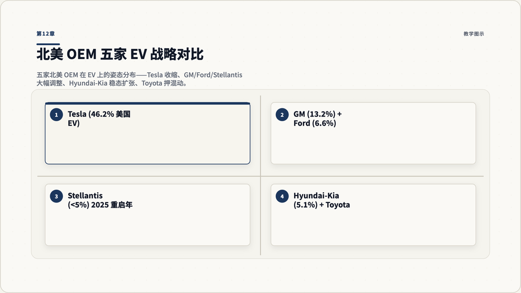

第12章：北美 OEM 五家 EV 战略对比

### 12.7 BD 对话的回收点

第一，**北美 OEM 的”EV 退潮”不是放弃 EV，而是放慢 EV 速度**。所有公司都在保留 EV 产能和产品，但把 2024-2026 的扩张速度大幅调低。这意味着北美 OEM 没准备好接住消费者需求——这是中国 EV / 韩国 EV 持续抢份额的窗口。

第二，五家 OEM 的合作偏好不同：

- GM 跟韩国 LG / SK 合作多
- Ford 跟宁德时代有 LRS 合作（密歇根 Marshall 工厂）
- Stellantis 跟 LG 合资 NextStar Energy（加拿大温莎）
- Toyota 自己投，且持续投全固态电池研究
- Hyundai 跟 SK On 在乔治亚建电池厂

如果你的 BD 对象是中国电池或零部件厂家，**Ford 是中国电池技术最容易切入的客户**（已有先例），其次是 Stellantis（财务危机让它对技术成本敏感）。Toyota 是中国厂家最难切入的客户（技术自有，文化封闭）。

第三，**所有 OEM 都在等待 2027-2028 的下一代电池平台**——这是 BD 工作的中期窗口。当下不签约，2027 后基本就晚了。

### 12.8 章末检查点

> “为什么北美 OEM 都在 2024-2025 大幅缩减 EV 投资，但同时所有人都在 2027-2028 押下一代电池？”

提示：当下市场需求增速放缓 + 30D 废止 = 短期亏损扩大；同时 2030-2035 年监管要求（CARB ZEV mandate、加拿大 ZEV mandate）不可逆 = 长期必须有产品。这种”短期收缩 + 长期下注”的姿态，对 BD 工作是双重信号：当下成交难，但长期合作的窗口反而打开了——因为 OEM 没有自己一家完成下一代平台的能力，必须合作。

## 第13章 中国车企出海北美的真实路径与障碍

把中国整车 / 电池 / 零部件厂家”进北美”的所有可能路径放在一张表上：

| 路径 | 适用对象 | 主要障碍 | 时间窗口 |
| --- | --- | --- | --- |
| **直接出口** | 几乎不可能（100% 关税） | 关税 + 30D + UFLPA | 已经关闭 |
| **墨西哥工厂** | 整车（USMCA 关税豁免） | MOFCOM 审批 + 反规避调查 | 2025-2030 |
| **加拿大配额** | 整车（2026 年 49,000 辆） | 配额分配机制不明 | 2026-2028 |
| **LRS 技术授权** | 电池 / 零部件（无股权） | OEM 配合度 + IRA 合规审查 | 2024-2030 |
| **欧洲转出口** | 整车（欧洲生产，关税分类不同） | 欧洲 EU 反补贴关税 | 部分可行 |
| **东南亚 / 拉美中转** | 整车（绕道，关税分类调整） | 美 / 加 反规避调查 | 越来越窄 |
| **商用车 / 巴士** | 商用车（关税类别不同，UFLPA 较少触及） | 市场容量小 | 持续可行 |

每一条路径都有”窗口期”。BD 工作的核心是判断哪条窗口对当下客户最优，并提前 12-18 个月布局。

### 13.2 墨西哥路径：BYD / 上汽 / 长城的赌注

USMCA（美 / 墨 / 加自由贸易协定）规定：在墨西哥本地生产、且本地化率 75% 以上的整车，可以免关税进美国。这是过去十几年丰田、本田、福特等利用墨西哥工厂的核心逻辑。

中国车企在 2022-2024 年大举宣布墨西哥工厂计划：

- **BYD**：宣布墨西哥两座工厂计划，初期目标年产 150,000 辆（部分报道甚至提到 50 万辆，本手册采用”据报道 150,000 辆”的保守版本）
- **上汽（SAIC）/ MG**：墨西哥 Mexico 工厂，2024 年规划
- **长城（Great Wall）**：墨西哥工厂规划，2023 年宣布
- **奇瑞**：阿根廷 / 巴西工厂 + 墨西哥可能性

但 2024 年下半年起，墨西哥路径出现严重问题：

这条路径在 2026 年仍有可能性，但比 2022 年想象的难得多。

### 13.3 加拿大配额路径：2026 年的窗口

2026 年 3 月加拿大宣布的 49,000 辆 / 6.1% 关税配额，是中国 EV 进北美的第一次”官方开口”。

这个配额的具体分配机制（哪些厂家、哪些车型、按什么标准）2026 年 5 月仍在政策制定中。可能的分配维度：

- **按厂家**：按申请顺序 / 按规模 / 按本土化承诺
- **按车型**：限纯电（BEV）？是否含插混（PHEV）？
- **按价格段**：限低价段（$50k 以下加元）？
- **按本地化承诺**：要求厂家承诺在加拿大设展厅 / 服务网络 / 充电桩共建

任何一家中国 EV 厂家想拿到这 49,000 配额的一部分，都需要在 2026 年 H1 启动加拿大本地化前期布局——展厅选址、服务伙伴接洽、政府关系。这是 BD 工作的最具体窗口。

### 13.4 LRS 技术授权路径：宁德时代 + 福特模式

LRS = License, Royalty, Services（许可、版税、服务）。

宁德时代 + 福特的 Marshall 工厂（密歇根州）是这条路径的标杆案例。基本结构：

- 工厂由福特百分百持有
- 宁德时代提供电池技术、生产工艺、设备清单、培训
- 福特付一次性技术许可费 + 持续的服务费 / 版税
- 宁德时代不持股、不掌控管理

这套结构的逻辑：从美国监管角度看，工厂是美国公司持有，不算”中国实体”——理论上 IRA 30D / FEOC 合规（虽然 IRS 仍在解释边界）。

LRS 模式可以扩展到其他中国电池 / 电机 / 零部件厂家：

- **比亚迪 / 宁德 / 中航锂电的电池授权**：跟 GM、Stellantis、Rivian 谈
- **华为 / 大疆系的智能驾驶授权**：跟新势力或新创业 OEM 谈
- **小米的电控系统 / 软件平台**：跟二线 OEM 谈

但这条路径有三个限制：

- OEM 必须有大资本投入（建工厂、招团队）——只有大 OEM 能做
- IRA / FEOC 解释仍在变——2026 后规则可能收紧到禁止这类合作
- 政治风险——任何一次美中关系恶化都会重新评估这类合作

### 13.5 商用车 / 巴士路径：低调但持续

中国新能源商用车（电动卡车、电动巴士）在美国的存在度低，但持续。比亚迪在加州兰开斯特建过电动巴士厂——主要客户是市政公交局（LA Metro、SeaTac 等）。

商用车在美国 / 加拿大的关税结构跟乘用车不同。Section 301 的 100% 关税主要针对乘用车，商用车关税相对较低（虽然 2024-2025 也在涨）。UFLPA 对商用车的拦截力度也较低。

这条路径销量天花板低（北美一年电动巴士市场约几千台），但作为”建立北美生产经验和品牌信任”的滩头阵地，仍然有价值。

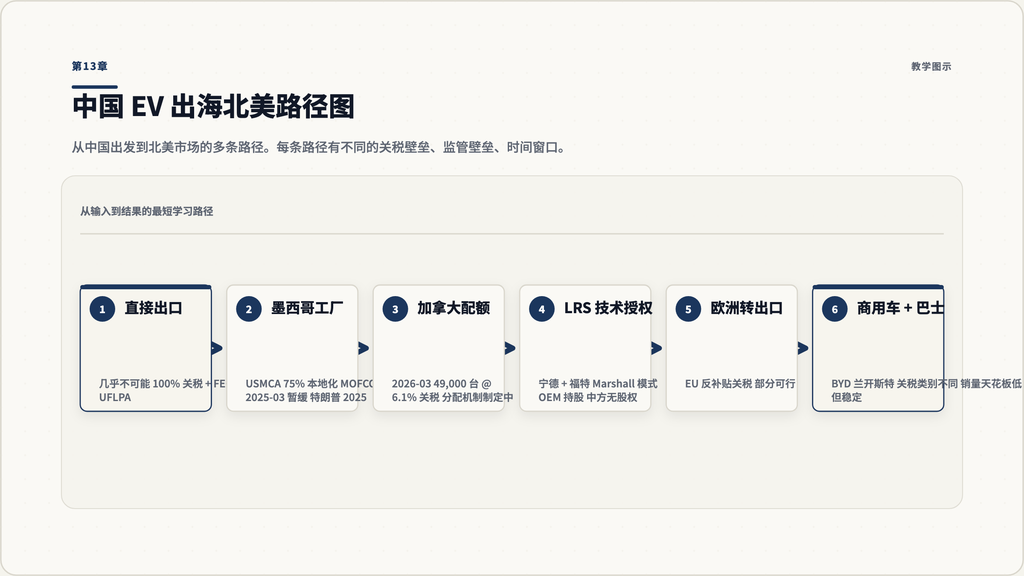

第13章：中国 EV 出海北美路径图

**图 13.1：从中国出发到北美市场的多条路径。每条路径都有不同的关税壁垒、监管壁垒、时间窗口。墨西哥路径在 2025 后大幅收紧；加拿大配额是新窗口；LRS 是当下最可行的电池路径；商用车是低速但稳定的滩头。**

### 13.6 BD 对话的回收点

第一，**不要相信”中国 EV 进北美的捷径”**。所有捷径都已经被监管补完。靠墨西哥、靠绕道、靠改名——这些路径在 2024-2025 都被反规避调查覆盖。剩下的只有”用时间换合规”的长期路径。

第二，**LRS 技术授权是当下最实际的进入模式**。任何想做”中国零部件 / 电池进北美 BD”的工作，都应该把 LRS 当成默认结构来研究——理解福特 / 宁德 Marshall 工厂的合同结构、IRS 合规边界、风险分担模型。

第三，**加拿大配额是 2026 唯一明确的整车进入窗口**。如果一家中国整车厂家在 2026 年没拿到加拿大配额，那它在北美 2030 年前几乎没有第二个整车进入机会。这件事的紧迫程度和资源优先级，应该是任何中国 EV 海外业务的”头号优先”。

### 13.7 章末检查点

> “如果你是一家中国 EV 厂家的海外业务负责人，2026 年你最大的资源应该分配在哪个路径？”

提示：不同厂家答案不同。BYD（垂直整合 + 商用车 + 电池授权）可能选择”加拿大配额 + 商用车 + 电池 LRS”三线并行；蔚来 / 小鹏（品牌+智能驾驶）可能选择”加拿大配额 + 欧洲转出口 + 智能驾驶授权”；宁德时代（电池为根）选择”LRS + 北美建厂”。理解每家的”出海重心”是 BD 工作判断对手的基础。

## 第14章 BD 视角：人物地图、媒体地图、对话工具箱

### 14.1 你要认识的不是个人，是组织 + 角色

加拿大 EV BD 的人物地图，不应该是一份”谁是 CEO”的名单——那种名单一年就过期。应该是一张**组织 + 角色 + 触达通道**的地图。

把这张地图分成五个圈：

**第一圈：政府与产业政策机构** - **联邦层（Ottawa）**：Innovation, Science and Economic Development Canada (ISED)、Transport Canada (TC)、Natural Resources Canada (NRCan)、CBSA（海关） - **省级**：Invest Ontario（安大略投资署）、Investissement Québec、Invest in Canada、Invest Alberta - **行业商会**：CVMA（Canadian Vehicle Manufacturers’ Association，代表 Big 3）、GAC（Global Automakers of Canada，代表丰田 / 本田 / 现代起亚等）

触达通道：商会会员单位 + 政府关系咨询公司（Hill+Knowlton、Crestview Strategy 等）。

**第二圈：OEM 北美 / 加拿大业务部门** - **GM Canada / Ford Canada / Stellantis Canada / Toyota Canada / Hyundai Auto Canada / Honda Canada** - **关键角色**：北美/加拿大区供应链总监、产品规划总监、政府关系 VP、电池战略负责人

注意：不点名具体高管（这层人三个月可能换岗）。BD 对话里描述对方时用角色而非名字。

**第三圈：电池与零部件供应链** - **加拿大本土**：Magna International（最大汽车零部件商）、Linamar、Martinrea、PowerCo（VW 系）、NextStar Energy（LG+Stellantis） - **韩系驻加**：LG Energy Solutions Canada、SK On Canada - **欧系**：BMW Canada、Mercedes-Benz Canada（小但战略上要看）

**第四圈：充电 / 基础设施 / 服务商** - **充电运营商**：Flo（加拿大本土领头）、Petro-Canada Electric Highway、Electrify Canada、Tesla Supercharger 加拿大 - **dealer 集团**：AutoCanada Inc.（加拿大上市，全国最大 dealer 集团）、Quebecor、Pfaff Automotive Partners

**第五圈：金融 / 法律 / 咨询服务方** - **银行 / 融资**：EDC（Export Development Canada）、BDC（Business Development Bank of Canada） - **法律事务所**：Osler / Stikeman Elliott / McCarthy Tétrault（贸易和监管专长） - **咨询公司**：McKinsey Canada / Bain Canada / 安永 EY / Roland Berger（汽车产业咨询）

### 14.2 你必须每周看的媒体

BD 工作的信息流是肌肉记忆——必须每周固定时间扫的资源：

**英文产业媒体（每周必看）：** - **InsideEVs**：全球 EV 销量、车型评测（insideevs.com） - **Electrek**：EV 行业新闻 + Tesla 重点跟踪（electrek.co） - **Cox Automotive Insights**：美国 EV 月度市场报告（[coxautoinc.com/insights-hub](https://www.coxautoinc.com/insights-hub/)） - **Reuters Auto**：行业大新闻、并购、政策（[reuters.com/business/autos-transportation](https://www.reuters.com/business/autos-transportation/)） - **Automotive News**：北美整车厂深度报道（订阅制） - **Auto Forecast Solutions (AFS)**：北美汽车产能预测（订阅制） - **S&P Global Mobility**：北美产业链数据（订阅制）

**加拿大本地媒体（每周必看）：** - **Electric Autonomy Canada**：加拿大 EV 政策和产业新闻（electricautonomy.ca） - **The Globe and Mail Auto**：加拿大主流商业媒体的汽车板块 - **Driving.ca**：加拿大消费者级汽车媒体（影响政策舆论）

**中文产业媒体（每周必看）：** - **CnEVPost**：中国 EV 英文新闻（cnevpost.com） - **盖世汽车 / 第一电动 / 汽车之家 / 高工锂电**：中文产业媒体（如果懂中文） - **晚点 LatePost 汽车专栏**：中国 EV 深度报道

**官方数据源（每月核对一次）：** - **IEA Global EV Outlook**：[iea.org/reports/global-ev-outlook](https://www.iea.org/reports/global-ev-outlook-2025/) 每年 4 月更新 - **Transport Canada ZEV 数据**：政府开放数据 - **USTR Section 301 公告**：ustr.gov 每次重大变化都会公告 - **US Treasury 30D / 45W FAQ**：treasury.gov - **CBP UFLPA Entity List**：cbp.gov/trade/forced-labor/UFLPA

### 14.3 对话工具箱：六种 BD 开场

把这六句话练熟。它们对应六种最常见的 BD 对话场景：

**1. 跟 OEM 北美电池采购负责人开场：** “我注意到你们的下一代电池平台 2027 量产——你们对宁德时代 LRS 模式的看法，跟你们去年公开说的有变化吗？” （这句话假设对方知道宁德/福特模式，立刻把对话拉到结构层面，不是产品层面。）

**2. 跟加拿大 dealer 集团高管开场：** “加拿大 2026 年 49,000 辆配额你们这边在准备吗？你们的销售网络在哪几个省最准备好接 EV？” （dealer 集团对配额有强烈兴趣，因为这是新增长来源。）

**3. 跟充电运营商开场：** “NACS 转换你们这边在哪几个站完成了？J3400 桩跟 CCS 桩的成本差大吗？” （让对方解释技术细节是检验真伪行家的方法。）

**4. 跟政府关系部门开场：** “我们在评估几个省的产业政策，你能帮我比较一下安大略和魁北克在电池项目上的差异吗？” （把对话转到对方擅长的”政策对比”领域。）

**5. 跟咨询公司或行业分析师开场：** “你们怎么看 30D 废止后，韩系 OEM 在北美的位置变化？Hyundai-Kia 会不会变成最大赢家？” （用一个新近政策变化作为切入，立刻展示你跟得上节奏。）

**6. 跟中国 EV 厂家海外业务负责人开场：** “你们这次墨西哥工厂的 MOFCOM 审批状态是？加拿大配额你们的判断是怎么分配的？” （直接问对方最痛的两个点——这是对话能不能深入的关键。）

### 14.4 你必须能回答的十个”压力问题”

模拟面试或客户压力测试时，对方最爱问的十个问题：

1. “美国 IRA 30D 已经废止了，那对中国 EV 是好消息还是坏消息？” （标准答案：对中国整车不好（窗口反正关着），对中国电池 LRS 反而中性。）
2. “你怎么看 BYD 进加拿大的可能性？时间线？” （答案：2026 年配额是最快窗口；2027 年看墨西哥工厂能不能批；2028+ 看 USMCA 谈判结果。）
3. “为什么 NACS 把 CCS 干掉了？” （标准答案：Tesla Supercharger 网络规模 + 体验领先 + Ford 2023 战略选择倒推 + SAE J3400 标准化。）
4. “宁德时代和 BYD 在电池上的根本区别是什么？” （标准答案：宁德是电池为产品（卖给所有人），BYD 是电池为内部资源（自己整车用）。）
5. “FEOC 怎么影响福特 Marshall 工厂？” （标准答案：LRS 模式 + 福特持股 = 理论合规，但 IRS 解释仍在变。）
6. “魁北克 EV 渗透率是 33%，为什么这么高？” （标准答案：省级补贴 + ZEV mandate + 充电网络 + 寒地不影响购买决策的政治文化。）
7. “Tesla 在 2025 年份额掉了 3 个百分点，主要让给谁了？” （标准答案：GM、Hyundai-Kia、福特，Cox 数据可证。）
8. “中国新势力（蔚小理小米）的最大问题是什么？” （标准答案：产能、毛利、全球化路径，三选一答。）
9. “加拿大跟美国 EV 政策同步度多少？” （标准答案：贸易壁垒同步（关税），财政补贴不同（30D 是美国独有，加拿大有 iZEV 但已暂停），ZEV mandate 各自有但加拿大略宽松。）
10. “如果你的客户是中国一家电池厂，你建议他们 2026 第一站去哪里？” （标准答案：加拿大（监管温和 + 配额 + 上游矿）+ 美国 LRS 模式同时启动；墨西哥推迟到 2027 后再评估。）

### 14.5 内部知识库的搭建

BD 工作不是靠记忆——是靠**可被搜索的知识库**。每周固定 2 小时维护这个库：

**文件结构（建议）：**

```
EV-BD-Knowledge/
├── 01-Policy/           # 政策追踪
│   ├── IRA-30D-timeline.md
│   ├── Section-301-tariff-history.md
│   ├── UFLPA-Entity-List-quarterly-snapshot.md
│   └── Canada-2026-quota-tracking.md
├── 02-OEM/              # 各 OEM 战略
│   ├── GM-2024-2025-decisions.md
│   ├── Ford-Model-e-loss-tracker.md
│   ├── Stellantis-2025-restart.md
│   ├── Toyota-hybrid-strategy.md
│   └── Hyundai-Kia-Metaplant.md
├── 03-Chinese-EV/       # 中国厂家追踪
│   ├── BYD-Mexico-status.md
│   ├── CATL-LRS-deals.md
│   ├── NIO-XPeng-Li-overseas.md
│   └── Xiaomi-quarterly.md
├── 04-Battery-Charging/ # 电池与充电
│   ├── Battery-market-share-quarterly.md
│   ├── Lithium-pricing.md
│   └── NACS-adoption-progress.md
├── 05-Canada-Specific/  # 加拿大本地
│   ├── Federal-policy-tracker.md
│   ├── Ontario-investment-history.md
│   ├── Quebec-iZEV-history.md
│   └── BC-ZEV-mandate-status.md
└── 06-Conversations/    # 对话和洞察记录
    ├── YYYY-MM-Person-Topic.md
    └── ...
```

每条记录都包含：日期、来源链接、原文摘录、你的判断、可能的 BD 行动。

每月固定一天（建议月底）做”地图复盘”——看哪些信息过时了、哪些新玩家进了、哪个客户的状态变了。

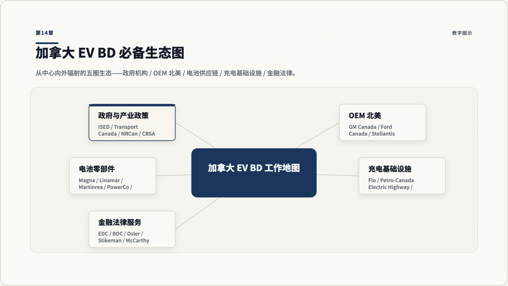

第14章：加拿大 EV BD 必备生态图

### 14.6 章末检查点（也是全书的最终检查点）

> “下周一上午 9 点，你要和一家中国电池厂的北美业务负责人开会。对方说：’我们想了解你们对 2026 年加拿大配额机制的判断，以及我们用 LRS 模式跟 GM 合作的可能路径。’你的开场陈述有 90 秒。”

把这 90 秒的开场写出来。

**参考结构：** - 前 30 秒：陈述对配额机制的判断（按你的最佳估计，是按申请顺序 / 按规模 / 按本地化承诺哪个为主？给一个具体观点） - 30-60 秒：陈述 LRS 跟 GM 合作的核心障碍（GM 自己 Ultium 在调整、对中国合作敏感度、IRS 解释边界） - 60-90 秒：陈述你的建议（同时启动加拿大配额申请 + LRS 跟非 GM OEM 谈起；为什么）

如果你能在 90 秒内不出错地讲完这个开场——基本就达到了本手册的目标。

## 结语：你刚走完一遍这 117 年

这本手册不是终点。它是底盘。

下周你走进一场 BD 会议或一次面试，记住第 1 章那个隐藏在背后的判断：

**对方不是在测试你的知识——他们在判断你有没有”看见这个行业怎么走到今天”的能力。**

知识可以查，判断要养。

这本手册帮你完成的是判断的底盘——117 年的故事熟了，2025 年发生的任何一条新闻，你都能立刻定位到这个故事的哪一章、哪一节、哪个力量。

下一个赛季见。

## 参考资料

所有数据和事件均来自下列公开资料。建议你在每次重要 BD 对话前 24-48 小时重新点开核对，特别是 2024-2025 的数字会持续刷新。

**官方政策与监管：**

- IEA Global EV Outlook 2025 — Trends in electric car markets: https://www.iea.org/reports/global-ev-outlook-2025/trends-in-electric-car-markets-2
- IEA Global EV Outlook 2024 — Trends in electric cars: https://www.iea.org/reports/global-ev-outlook-2024/trends-in-electric-cars
- USTR Section 301 Modifications (September 12, 2024): https://ustr.gov/sites/default/files/Section%20301%20Modifications%20Determination%20FRN%20(Sept%2012%202024)%20(FINAL).pdf
- US Treasury 30D Final Regulations (Federal Register, May 6, 2024): https://www.federalregister.gov/documents/2024/05/06/2024-09094/clean-vehicle-credits-under-sections-25e-and-30d-transfer-of-credits-critical-minerals-and-battery
- US Treasury IRA EV Tax Credit FAQ: https://home.treasury.gov/system/files/136/EV-Tax-Credit-FAQs.pdf
- CBP UFLPA Overview and Entity List: https://www.cbp.gov/trade/forced-labor/UFLPA
- USGS Mineral Commodity Summaries 2025 (Lithium): https://pubs.usgs.gov/periodicals/mcs2025/mcs2025-lithium.pdf
- Government of Canada — 100% tariff on Chinese-made EVs (via Electric Autonomy Canada coverage): https://electricautonomy.ca/policy-regulations/2024-08-27/canada-imposes-tariffs-on-chinese-made-evs-aluminum-steel/

**整车厂财报与披露：**

- GM Q4/FY 2025 results press release (SEC EDGAR): https://www.sec.gov/Archives/edgar/data/0001467858/000146785825000063/pressreleasefeb2025final.htm
- Stellantis FY2025 results (SEC EDGAR 6-K): https://www.sec.gov/Archives/edgar/data/0001605484/000160548426000019/stellantisnvfy2025pressrel.htm
- EVgo Q3 2024 8-K filings (SEC EDGAR): https://www.sec.gov/Archives/edgar/data/0001821159/000155837024015153/evgo-20241112xex99d1.htm

**产业数据与市场份额：**

- Cox Automotive / Kelley Blue Book US EV market 2024-2025 (via CleanTechnica): https://cleantechnica.com/2026/02/04/tesla-had-46-of-us-ev-market-in-2025-down-from-49-in-2024-gm-13-ford-7/
- Cox Automotive EV Market Monitor (April 2025): https://www.coxautoinc.com/insights-hub/ev-market-monitor-april-2025/
- WardsAuto US EV 2024 1.3M sales: https://www.wardsauto.com/news/archive-auto-electric-vehicle-sales-us-2024-increase-cox-automotive/737528/
- Electrek — BYD overtakes Tesla in EVs: https://electrek.co/2025/06/16/byd-overtakes-tesla-as-chinas-ev-giants-dominate-global-sales/
- InsideEVs — BYD top EV maker 2024: https://insideevs.com/news/746064/byd-beats-tesla-ev-production/
- CnEVPost — Global EV battery market share 2024: https://cnevpost.com/2025/02/11/global-ev-battery-market-share-2024/

**充电与基础设施：**

- Edmunds — GM adopts NACS: https://www.edmunds.com/car-news/new-gm-evs-will-adopt-tesla-charging-ports.html
- Wikipedia — North American Charging Standard / SAE J3400: https://en.wikipedia.org/wiki/North_American_Charging_Standard

**中国 EV 与出海路径：**

- CnEVPost — Xiaomi EV charging tie-ups with NIO XPeng Li Auto: https://cnevpost.com/2024/12/25/xiaomi-ev-announces-tie-ups-nio-xpeng-li-auto-charging/
- Carnewschina — Chinese auto analyst on NIO/XPeng/Li Auto consolidation outlook: https://carnewschina.com/2025/04/15/the-probability-of-nio-xpeng-and-li-auto-surviving-independently-in-the-next-three-years-is-zero-chinas-automotive-analysts-says/
- MexicoBusiness — BYD Mexico plant: https://mexicobusiness.news/automotive/news/byd-mexico-confirms-new-plant-construction
- Electrek — Chinese automakers entering Canada 2026 quota: https://electrek.co/2026/05/06/chinese-ev-automakers-canada-byd-chery-geely-tesla-benefits/
- Electric Autonomy Canada — Canada 100% tariff: https://electricautonomy.ca/policy-regulations/2024-08-27/canada-imposes-tariffs-on-chinese-made-evs-aluminum-steel/

**历史与百科参考：**

- Wikipedia — Tesla, Inc.: https://en.wikipedia.org/wiki/Tesla,_Inc.
- History.com — Ford assembly line, December 1, 1913: https://www.history.com/this-day-in-history/fords-assembly-line-starts-rolling
- Ford Corporate — Highland Park Plant Legacy: https://corporate.ford.com/articles/history/highland-park/
- Wikipedia — Alfred P. Sloan: https://en.wikipedia.org/wiki/Alfred_P._Sloan
- Wikipedia — Effects of 2008-2010 automotive industry crisis on the United States: https://en.wikipedia.org/wiki/Effects_of_the_2008%E2%80%932010_automotive_industry_crisis_on_the_United_States
- Wikipedia — Toyota Production System: https://en.wikipedia.org/wiki/Toyota_Production_System
- Wikipedia — Tesla US Dealership Disputes: https://en.wikipedia.org/wiki/Tesla_US_dealership_disputes
- CarBuzz — 1973 oil crisis impact: https://carbuzz.com/how-the-oil-crisis-and-the-epa-changed-the-automotive-industry/
- Lean Enterprise Institute — Toyota Production System: https://www.lean.org/lexicon-terms/toyota-production-system/

**赛前必做：**

每次 BD 对话或面试前 48 小时，**至少**核对以下三个数字的最新版本： 1. 美国 EV 季度市场份额（Cox Automotive 月度更新） 2. 美国 IRA 政策最新状态（30D 已废止后续是否有新法案） 3. 加拿大 49,000 辆配额的分配机制状态（Transport Canada / NRCan 公告）

这三个数据每月都可能刷新。把它们装在你的”BD 前 48 小时清单”里。